# Notebook

SENTIMENT ANALYSIS OF RESPONSES FROM BENEFICIARIES TO LIVELIHOOD SUBPROJECTS IN ZAMBIA Author: Nathan Namatama Institution: Leibniz Institute of Ecological Urban and Regional Development and Technical University of Dresden Year: 2024 Related Publication: The effects and impacts of livelihood activities and unplanned human settlement growth on greenspace and wetland landscapes in Zambia: A case of the three areas of the Pilot Programme for Climate Resilience (PPCR)

1. Importing Libraries The liberarries that are needed for conducting the analysis are installed and downloaded

```python
import nltk
import re
from collections import Counter
from nltk.probability import FreqDist
from nltk.corpus import stopwords
from nltk.stem import WordNetLemmatizer
from nltk.tokenize import sent_tokenize
from nltk.tokenize import word_tokenize
from nltk import sent_tokenize, word_tokenize, pos_tag
import pandas as pd
import numpy as np
import matplotlib.pyplot as plt
import seaborn as sns
import io
from io import StringIO
import csv
import unicodedata
import string
import plotly
import plotly.express as px
import plot_likert
from sklearn.model_selection import train_test_split
%matplotlib inline
from nbconvert import HTMLExporter
import nbformat
```

```python
nltk.download('punkt_tab')
nltk.download('punkt')
nltk.download('stopwords')
nltk.download('wordnet')
```

```
True
```

2. Reading the Excel Table The csv file is converted to a padas dataframe

```python
df = pd.read_csv(r"D:\DataAnalysis\Social_Survey_Questionnaire_for_Beneficiaries_0.csv")
pd.set_option('display.max_colwidth', None)
```

```python
type(df)
```

```
pandas.core.frame.DataFrame
```

```python
df
```

|  | ObjectID | GlobalID | Logo_TUDresden | Logo_IOER | Name of Researcher: Nathan Namatama | Email: n.namatama@ioer.de | Logo | The social survey questionnaire is meant to gather information on three things: | •\t How social and ecological systems are managed: This includes understanding how communities and natural environments are governed. | •\t How people's livelihood activities change the landscape: This looks at how different livelihoods impact the land, environment as well as the land use land cover change. | ... | Specify:.2 | Specify:.3 | Specify:.4 | Specify:.5 | Specify:.6 | Specify:.7 | Specify:.8 | Specify:.9 | x | y |
| --- | --- | --- | --- | --- | --- | --- | --- | --- | --- | --- | --- | --- | --- | --- | --- | --- | --- | --- | --- | --- | --- |
| 0 | 1 | b8330d48-b014-43e9-83ee-65e2eef11c4f | NaN | NaN | NaN | NaN | NaN | NaN | NaN | NaN | ... | NaN | NaN | NaN | NaN | NaN | NaN | NaN | NaN | 0.000000 | 0.000000 |
| 1 | 2 | bb5a8756-5fa8-425b-b48e-590943d89688 | NaN | NaN | NaN | NaN | NaN | NaN | NaN | NaN | ... | NaN | NaN | NaN | NaN | NaN | NaN | NaN | NaN | 0.000000 | 0.000000 |
| 2 | 3 | 4330fe39-a7c1-4c52-adf5-80b1ea153095 | NaN | NaN | NaN | NaN | NaN | NaN | NaN | NaN | ... | NaN | NaN | NaN | NaN | NaN | NaN | NaN | NaN | 29.628698 | -11.663522 |
| 3 | 4 | a65873e1-686d-4f03-973d-a4620eb9798b | NaN | NaN | NaN | NaN | NaN | NaN | NaN | NaN | ... | NaN | NaN | NaN | NaN | NaN | NaN | NaN | NaN | 29.441380 | -11.549158 |
| 4 | 5 | d9d192e3-225a-4e27-b439-a5b881a0e26e | NaN | NaN | NaN | NaN | NaN | NaN | NaN | NaN | ... | NaN | All the cannot change except for hunting | Only the protection nature the others are not important | NaN | NaN | NaN | When the people come them they give us imformation | NaN | 29.441459 | -11.549211 |
| ... | ... | ... | ... | ... | ... | ... | ... | ... | ... | ... | ... | ... | ... | ... | ... | ... | ... | ... | ... | ... | ... |
| 145 | 146 | 0b3b2aad-707c-46c2-ac09-4d38e14e1d3d | NaN | NaN | NaN | NaN | NaN | NaN | NaN | NaN | ... | NaN | NaN | NaN | NaN | NaN | NaN | NaN | NaN | 23.202439 | -15.374461 |
| 146 | 147 | de6da6cc-c6e1-4114-adf0-14a03a50354d | NaN | NaN | NaN | NaN | NaN | NaN | NaN | NaN | ... | NaN | NaN | NaN | NaN | NaN | NaN | Tgrought word of mouth | Fromm pin | 23.201394 | -15.377789 |
| 147 | 148 | 1dd0393e-d55a-4c1c-8052-8c678c177fd3 | NaN | NaN | NaN | NaN | NaN | NaN | NaN | NaN | ... | NaN | NaN | NaN | NaN | NaN | NaN | Through phones and through word mouth | NaN | 23.176112 | -15.387063 |
| 148 | 149 | 49eec3a2-09ae-42f2-b670-b526478ffd0b | NaN | NaN | NaN | NaN | NaN | NaN | NaN | NaN | ... | NaN | NaN | NaN | NaN | NaN | NaN | Through phone and word of mouth | NaN | 23.173384 | -15.389017 |
| 149 | 150 | c6b480fe-5961-44c3-b781-bb7d7bb5a1ad | NaN | NaN | NaN | NaN | NaN | NaN | NaN | NaN | ... | NaN | NaN | NaN | NaN | NaN | NaN | Phones | NaN | 23.174897 | -15.384159 |

150 rows Ã— 120 columns

```python
df.shape
```

```
(150, 120)
```

Missing Values

3. Missing values The Pandas Dataframe is checked for mising values

```python
df.isnull().sum()
```

```
ObjectID                                 0
GlobalID                                 0
Logo_TUDresden                         150
Logo_IOER                              150
Name of Researcher: Nathan Namatama    150
                                      ...
Specify:.7                             150
Specify:.8                              60
Specify:.9                             126
x                                        0
y                                        0
Length: 120, dtype: int64
```

```python
df.isnull().sum().sort_values(ascending=False)
```

```
Logo_IOER                              150
Logo_TUDresden                         150
Email: n.namatama@ioer.de              150
Name of Researcher: Nathan Namatama    150
Logo                                   150
                                      ...
Editor                                   0
CreationDate                             0
Creator                                  0
x                                        0
y                                        0
Length: 120, dtype: int64
```

```python
#df.dropna(inplace=True)
```

4. Deleting Columnns There are 120 columns and 85 columns were removed from the pandas dataframe so as to focus on specific columns that have questtions in regards to livelihood and landscape transfromation

```python
df1=df.drop(df.columns[[1,2,3,4,5,6,7,8,9,10,11,12,13,14,22,23,24,25,26,27,28,29,30,31,32,33,34,35,36,37,38,39,40,41,42,43,44,45,46,47,48,49,50,51,75,76,77,78,79,80,81,82,83,84,85,86,87,88,89,90,91,92,93,94,95,96,97,98,99,100,101,102,103,104,105,106,107,108,109,110,111,116,117,118,119]], axis = 1)
```

```python
df1
```

|  | ObjectID | 6. Ward Name | 7. Sub Project Name | 8. Type of Livelihood | 9. Size (Lima) | 12. Name of main project | 13. Do you represent other beneficiaries? | 14. How many beneficiaries do you represent? | 45. Are there cultural practices that hinder the sustainable management of Forests, Wetlands, National Game Parks and Biodiversity? | 46. What reasons can you give for your answer above? | ... | 62. Are there new livelihood projects that you think of that have never been implemented? | 63. Do you think the livelihood subprojects are contributing to the sustainability of landscapes? | 64. Which livelihood is a major contributor to landscape transformation? | 65. What reasons can you give for your answer above? | 66. Which type of landscape do you depend on much for a livelihood? | 67. What reasons can you give for your answer above? | Specify:.4 | Specify:.5 | Specify:.6 | Specify:.7 |
| --- | --- | --- | --- | --- | --- | --- | --- | --- | --- | --- | --- | --- | --- | --- | --- | --- | --- | --- | --- | --- | --- |
| 0 | 1 | Isamba ward | Isamba coperatives | Goat rearing | 8to12Lima_Size | TRALARD_LNM | yes | Greaterthan40People_Many | Agree_Likert | It has never happed before in his life time | ... | Strongly_Disagree_Likert | Strongly_Disagree_Likert | Wood_Extraction | The trees have been depleted and it has caused reduced rainfall | Agriculture_Areas_Dependent | He caltivates a large area of land so that some crops can be sold for a livelihood | NaN | NaN | NaN | NaN |
| 1 | 2 | Isamba ward | Misenga cooperative multipurpose society | Goat rearing, Gardening, Fruit trees | Greaterthan16Lima_Size | TRALARD_LNM | yes | Greaterthan40People_Many | Strongly_Agree_Likert | There is need to harvest tree when they have fully grown the same applies to biodiversity | ... | Strongly_Agree_Likert | Strongly_Agree_Likert | Land_Agriculture | Because i have to clear the land gor agriculture for to plant crops hence the the lsndscsoe change | Wetlands_Dependent | Tje killing of fish is the source of income in thix area | NaN | NaN | NaN | NaN |
| 2 | 3 | Isamba | Ninge Cooperative | Goat Rearing, Agricuture-cassava | Greaterthan16Lima_Size | TRALARD_LNM | yes | Greaterthan40People_Many | Strongly_Disagree_Likert | There are no customary practices that hinder sustainable management | ... | Strongly_Disagree_Likert | Strongly_Disagree_Likert | Wood_Extraction | There would a reduction in the number of trees hence contributing to clinate chsnge | Agriculture_Areas_Dependent,Wetlands_Dependent | He depends much on agriculture the most than fish because the fish can be depleted | NaN | NaN | NaN | NaN |
| 3 | 4 | Isamba ward | Twikatene copperatives | Goat rearing and Fish farming and garden of vegitable and onnoind | Greaterthan16Lima_Size | TRALARD_LNM | yes | Greaterthan40People_Many | Strongly_Agree_Likert | There are rotations made on the land when cultivation to ensure fetility of soil | ... | Strongly_Disagree_Likert | Strongly_Agree_Likert | Land_Agriculture | Because it requires a huge land than the others the making chaocoal | Agriculture_Areas_Dependent | Food is the main source of livelihood thus without it there is no way to earn a living | NaN | NaN | NaN | NaN |
| 4 | 5 | Isamba ward | Changwena women club | Chicken rearing ablnd an orchard | Lessthan4Lima_Size | TRALARD_LNM | NaN | 20to30People_Many | Strongly_Disagree_Likert | There is nothing | ... | Strongly_Agree_Likert | Strongly_Agree_Likert | Land_Agriculture | Because people cut down tree for farmimg but they never use the land but he would prefer they use a small portion to leave trees as a home of willd animals | Forest_Dependent,Wetlands_Dependent | The water is used for gardening and other things | Only the protection nature the others are not important | NaN | NaN | NaN |
| ... | ... | ... | ... | ... | ... | ... | ... | ... | ... | ... | ... | ... | ... | ... | ... | ... | ... | ... | ... | ... | ... |
| 145 | 146 | Yeta | NaN | Biochar | NaN | EbA_CENTRAL_MUCHINGA_LUAPULA | NaN | NaN | NaN | NaN | ... | NaN | NaN | NaN | NaN | NaN | NaN | NaN | NaN | NaN | NaN |
| 146 | 147 | Yeta | Biochar | Gardening | Lessthan4Lima_Size | PIN_WESTERN | no | NaN | Strongly_Disagree_Likert | There is nothing | ... | NaN | Strongly_Agree_Likert | Wood_Extraction | They use chitemen system of just cuttingbtrees for choarcaol | Agriculture_Areas_Dependent | We farmers | NaN | NaN | NaN | NaN |
| 147 | 148 | Yeta | Biochar | Gardening | Lessthan4Lima_Size | PIN_WESTERN | no | NaN | Strongly_Disagree_Likert | There is nthing | ... | Strongly_Agree_Likert | Strongly_Agree_Likert | Wood_Extraction | The trees and cut and make charcoal the do bnot grow | Agriculture_Areas_Dependent | Thats where we get food and money | NaN | NaN | NaN | NaN |
| 148 | 149 | Yeta | B iochar | Gardenning | 8to12Lima_Size | PIN_WESTERN | no | NaN | Strongly_Disagree_Likert | There is nothing | ... | Strongly_Disagree_Likert | Strongly_Agree_Likert | Uncontrolled_Fires | It distroys everythin on it ways | Agriculture_Areas_Dependent | That were our food crops are found | NaN | NaN | NaN | NaN |
| 149 | 150 | Yeta ward | Piggery, fishponds and gardening | Fish ponds and piggery and gerdening | Lessthan4Lima_Size | SCReBS_WESTERN | yes | 10to20People_Many | Strongly_Disagree_Likert | There is nothing | ... | Strongly_Agree_Likert | Strongly_Agree_Likert | Uncontrolled_Fires | It diatroys everything on its path | Wetlands_Dependent | Thats where we plant maize and rice | NaN | NaN | NaN | NaN |

150 rows Ã— 35 columns

5. Renaming Columns The headings of the columns were renamed for easy inclusion in the code

```python
df1.columns
```

```
Index(['ObjectID', '6. Ward Name', '7. Sub Project Name',
       '8. Type of Livelihood', '9. Size (Lima)', '12. Name of main project',
       '13. Do you represent other beneficiaries?',
       '14. How many beneficiaries do you represent?',
       '45. Are there cultural practices that hinder the sustainable management of Forests, Wetlands, National Game Parks and Biodiversity?',
       '46. What reasons can you give for your answer above?',
       '47. Do you think some cultural practices can be changed?',
       '48. Do you consider cultural aspects when formulating the livelihood projects?',
       '49. What reasons can you give for your answer above?',
       '50. What is the main purpose of landscapes (Forests, Water Bodies, Wetlandsâ€¦ etc.) in your livelihood?',
       '51. Do you think there is need to measure indicators when managing landscapes?',
       '52. How is your connection to nature like?',
       '53. What reasons can you give for your answer above?',
       '54. How long have you worked on this livelihood project?',
       '55. Does your livelihood depend on the natural resources for a living?',
       '56. Do you consider changing your livelihood strategy in future?',
       '57. Do you think it is easier to change your livelihood practices?',
       '58. Are you able to give reasons for your answer above in your ability to change your livelihood practices?',
       '59. Have the ecosystem services reduced from the inception of the project in your ward?',
       '60. Has the deforestation increased in the ward?',
       '61. Do you think protected areas are a hindrance to your livelihoods?',
       '62. Are there new livelihood projects that you think of that have never been implemented?',
       '63. Do you think the livelihood subprojects are contributing to the sustainability of landscapes?',
       '64. Which livelihood is a major contributor to landscape transformation?',
       '65. What reasons can you give for your answer above?',
       '66. Which type of landscape do you depend on much for a livelihood?',
       '67. What reasons can you give for your answer above?', 'Specify:.4',
       'Specify:.5', 'Specify:.6', 'Specify:.7'],
      dtype='object')
```

```python
df2=df1.rename(columns= {'1. Do you agree to take part in the above study?': 'Part_study',
                        '2. Do you know that your participation is voluntary and you are free to withdraw anytime?':'Participation_Voluntary',
                        '3. Do you give permission to the data that emerges to be used by the researchers only in an anonymised form?': 'Anonymised_Form',
                        '5. Date': 'Date',
                        '6. Ward Name': 'Ward_Name',
                        '7. Sub Project Name': 'Sub_Project_name',
                        '8. Type of Livelihood': 'Livelihood',
                        '9. Size (Lima)': 'Size',
                        '12. Name of main project': 'Name_Main_Project',
                        '13. Do you represent other beneficiaries?': 'Representing_Others',
                        '14. How many beneficiaries do you represent?': 'Number_Beneficiaries',
                        '45. Are there cultural practices that hinder the sustainable management of Forests, Wetlands, National Game Parks and Biodiversity?': 'Cultural_Practices_Hinder',
                        '46. What reasons can you give for your answer above?': 'Cultural_Practices_Hinder_Reason',
                        '47. Do you think some cultural practices can be changed?': 'Cultural_Practices_Changed',
                        '48. Do you consider cultural aspects when formulating the livelihood projects?': 'Cultural_Aspects_Considered',
                        '49. What reasons can you give for your answer above?': 'Cultural_Aspects_Considered_Reasons',
                        '50. What is the main purpose of landscapes (Forests, Water Bodies, Wetlandsâ€¦ etc.) in your livelihood?': 'Purpose_Landscape',
                        '51. Do you think there is need to measure indicators when managing landscapes?': 'Measure_Indicators',
                        '52. How is your connection to nature like?': 'Connection_Nature',
                        '53. What reasons can you give for your answer above?': 'Connection_Nature_Reasons',
                       '54. How long have you worked on this livelihood project?': 'Livelihood_Project',
                       '55. Does your livelihood depend on the natural resources for a living?': 'Livilihood_Depenedent',
                       '56. Do you consider changing your livelihood strategy in future?': 'Change_Livelihood',
                       '57. Do you think it is easier to change your livelihood practices?': 'Change_Livelihood_Easy',
                       '58. Are you able to give reasons for your answer above in your ability to change your livelihood practices?': 'Change_Livelihood_Easy_Reasons',
                       '59. Have the ecosystem services reduced from the inception of the project in your ward?': 'Ecosystem_Services_Reduced',
                       '60. Has the deforestation increased in the ward?': 'Deforestaion_Increased',
                       '61. Do you think protected areas are a hindrance to your livelihoods?': 'Protected_Areas_Hinderarnce_Livelihood',
                       '62. Are there new livelihood projects that you think of that have never been implemented?': 'New_Livelihood_Projects',
                       '63. Do you think the livelihood subprojects are contributing to the sustainability of landscapes?': 'Subprojects_Sustainability_Contribution',
                       '64. Which livelihood is a major contributor to landscape transformation?': 'Contributor_Landscape_Transformation',
                       '65. What reasons can you give for your answer above?': 'Contributor_Landscape_Transformation_Reasons',
                       '66. Which type of landscape do you depend on much for a livelihood?': 'Landscape_Depended_Livelihood',
                       '67. What reasons can you give for your answer above?': 'Landscape_Depeneded_Livelihood_Reasons',
                       'Specify:.4': 'Purpose_Landscape_Specific',
                       'Specify:.5': 'Connection_Nature_Specific',
                       'Specify:.6': 'Contributor_Landscape_Transformation_Specific',
                       'Specify:.7': 'Landscape_Depended_Livelihood_Specific'})
```

```python
df2
```

|  | ObjectID | Ward_Name | Sub_Project_name | Livelihood | Size | Name_Main_Project | Representing_Others | Number_Beneficiaries | Cultural_Practices_Hinder | Cultural_Practices_Hinder_Reason | ... | New_Livelihood_Projects | Subprojects_Sustainability_Contribution | Contributor_Landscape_Transformation | Contributor_Landscape_Transformation_Reasons | Landscape_Depended_Livelihood | Landscape_Depeneded_Livelihood_Reasons | Purpose_Landscape_Specific | Connection_Nature_Specific | Contributor_Landscape_Transformation_Specific | Landscape_Depended_Livelihood_Specific |
| --- | --- | --- | --- | --- | --- | --- | --- | --- | --- | --- | --- | --- | --- | --- | --- | --- | --- | --- | --- | --- | --- |
| 0 | 1 | Isamba ward | Isamba coperatives | Goat rearing | 8to12Lima_Size | TRALARD_LNM | yes | Greaterthan40People_Many | Agree_Likert | It has never happed before in his life time | ... | Strongly_Disagree_Likert | Strongly_Disagree_Likert | Wood_Extraction | The trees have been depleted and it has caused reduced rainfall | Agriculture_Areas_Dependent | He caltivates a large area of land so that some crops can be sold for a livelihood | NaN | NaN | NaN | NaN |
| 1 | 2 | Isamba ward | Misenga cooperative multipurpose society | Goat rearing, Gardening, Fruit trees | Greaterthan16Lima_Size | TRALARD_LNM | yes | Greaterthan40People_Many | Strongly_Agree_Likert | There is need to harvest tree when they have fully grown the same applies to biodiversity | ... | Strongly_Agree_Likert | Strongly_Agree_Likert | Land_Agriculture | Because i have to clear the land gor agriculture for to plant crops hence the the lsndscsoe change | Wetlands_Dependent | Tje killing of fish is the source of income in thix area | NaN | NaN | NaN | NaN |
| 2 | 3 | Isamba | Ninge Cooperative | Goat Rearing, Agricuture-cassava | Greaterthan16Lima_Size | TRALARD_LNM | yes | Greaterthan40People_Many | Strongly_Disagree_Likert | There are no customary practices that hinder sustainable management | ... | Strongly_Disagree_Likert | Strongly_Disagree_Likert | Wood_Extraction | There would a reduction in the number of trees hence contributing to clinate chsnge | Agriculture_Areas_Dependent,Wetlands_Dependent | He depends much on agriculture the most than fish because the fish can be depleted | NaN | NaN | NaN | NaN |
| 3 | 4 | Isamba ward | Twikatene copperatives | Goat rearing and Fish farming and garden of vegitable and onnoind | Greaterthan16Lima_Size | TRALARD_LNM | yes | Greaterthan40People_Many | Strongly_Agree_Likert | There are rotations made on the land when cultivation to ensure fetility of soil | ... | Strongly_Disagree_Likert | Strongly_Agree_Likert | Land_Agriculture | Because it requires a huge land than the others the making chaocoal | Agriculture_Areas_Dependent | Food is the main source of livelihood thus without it there is no way to earn a living | NaN | NaN | NaN | NaN |
| 4 | 5 | Isamba ward | Changwena women club | Chicken rearing ablnd an orchard | Lessthan4Lima_Size | TRALARD_LNM | NaN | 20to30People_Many | Strongly_Disagree_Likert | There is nothing | ... | Strongly_Agree_Likert | Strongly_Agree_Likert | Land_Agriculture | Because people cut down tree for farmimg but they never use the land but he would prefer they use a small portion to leave trees as a home of willd animals | Forest_Dependent,Wetlands_Dependent | The water is used for gardening and other things | Only the protection nature the others are not important | NaN | NaN | NaN |
| ... | ... | ... | ... | ... | ... | ... | ... | ... | ... | ... | ... | ... | ... | ... | ... | ... | ... | ... | ... | ... | ... |
| 145 | 146 | Yeta | NaN | Biochar | NaN | EbA_CENTRAL_MUCHINGA_LUAPULA | NaN | NaN | NaN | NaN | ... | NaN | NaN | NaN | NaN | NaN | NaN | NaN | NaN | NaN | NaN |
| 146 | 147 | Yeta | Biochar | Gardening | Lessthan4Lima_Size | PIN_WESTERN | no | NaN | Strongly_Disagree_Likert | There is nothing | ... | NaN | Strongly_Agree_Likert | Wood_Extraction | They use chitemen system of just cuttingbtrees for choarcaol | Agriculture_Areas_Dependent | We farmers | NaN | NaN | NaN | NaN |
| 147 | 148 | Yeta | Biochar | Gardening | Lessthan4Lima_Size | PIN_WESTERN | no | NaN | Strongly_Disagree_Likert | There is nthing | ... | Strongly_Agree_Likert | Strongly_Agree_Likert | Wood_Extraction | The trees and cut and make charcoal the do bnot grow | Agriculture_Areas_Dependent | Thats where we get food and money | NaN | NaN | NaN | NaN |
| 148 | 149 | Yeta | B iochar | Gardenning | 8to12Lima_Size | PIN_WESTERN | no | NaN | Strongly_Disagree_Likert | There is nothing | ... | Strongly_Disagree_Likert | Strongly_Agree_Likert | Uncontrolled_Fires | It distroys everythin on it ways | Agriculture_Areas_Dependent | That were our food crops are found | NaN | NaN | NaN | NaN |
| 149 | 150 | Yeta ward | Piggery, fishponds and gardening | Fish ponds and piggery and gerdening | Lessthan4Lima_Size | SCReBS_WESTERN | yes | 10to20People_Many | Strongly_Disagree_Likert | There is nothing | ... | Strongly_Agree_Likert | Strongly_Agree_Likert | Uncontrolled_Fires | It diatroys everything on its path | Wetlands_Dependent | Thats where we plant maize and rice | NaN | NaN | NaN | NaN |

150 rows Ã— 35 columns

6. Selection of Likert Scale Columns The columns that had likert scale responses were group in a single dataframe and they are 12 in number the columns were looking at the following questions as numbered in the questionaire: '45. Are there cultural practices that hinder the sustainable management of Forests, Wetlands, National Game Parks and Biodiversity? '47. Do you think some cultural practices can be changed?', '48. Do you consider cultural aspects when formulating the livelihood projects?', '51. Do you think there is need to measure indicators when managing landscapes?', '55. Does your livelihood depend on the natural resources for a living?', '56. Do you consider changing your livelihood strategy in future?', '57. Do you think it is easier to change your livelihood practices?', '59. Have the ecosystem services reduced from the inception of the project in your ward?', '60. Has the deforestation increased in the ward?', '61. Do you think protected areas are a hindrance to your livelihoods?', '62. Are there new livelihood projects that you think of that have never been implemented?', '63. Do you think the livelihood subprojects are contributing to the sustainability of landscapes?'

```python
df3=df2.drop(df2.columns[[0,1,2,3,4,5,6,7,9,12,13,15,16,17,21,27,28,29,30,31,32,33,34]], axis = 1)
```

```python
df3
```

|  | Cultural_Practices_Hinder | Cultural_Practices_Changed | Cultural_Aspects_Considered | Measure_Indicators | Livilihood_Depenedent | Change_Livelihood | Change_Livelihood_Easy | Ecosystem_Services_Reduced | Deforestaion_Increased | Protected_Areas_Hinderarnce_Livelihood | New_Livelihood_Projects | Subprojects_Sustainability_Contribution |
| --- | --- | --- | --- | --- | --- | --- | --- | --- | --- | --- | --- | --- |
| 0 | Agree_Likert | Undecided_Likert | Strongly_Disagree_Likert | Strongly_Agree_Likert | Strongly_Disagree_Likert | Agree_Likert | Strongly_Agree_Likert | Strongly_Agree_Likert | Strongly_Agree_Likert | Strongly_Agree_Likert | Strongly_Disagree_Likert | Strongly_Disagree_Likert |
| 1 | Strongly_Agree_Likert | Strongly_Agree_Likert | Strongly_Agree_Likert | Strongly_Agree_Likert | Strongly_Agree_Likert | Strongly_Agree_Likert | Strongly_Agree_Likert | Strongly_Agree_Likert | Strongly_Agree_Likert | Strongly_Disagree_Likert | Strongly_Agree_Likert | Strongly_Agree_Likert |
| 2 | Strongly_Disagree_Likert | Strongly_Disagree_Likert | Strongly_Disagree_Likert | Strongly_Agree_Likert | Strongly_Agree_Likert | Strongly_Disagree_Likert | Agree_Likert | Strongly_Agree_Likert | Strongly_Agree_Likert | Strongly_Disagree_Likert | Strongly_Disagree_Likert | Strongly_Disagree_Likert |
| 3 | Strongly_Agree_Likert | Strongly_Disagree_Likert | Strongly_Agree_Likert | Strongly_Agree_Likert | Strongly_Disagree_Likert | Disagree_Likert | Strongly_Disagree_Likert | Strongly_Disagree_Likert | Strongly_Disagree_Likert | Strongly_Disagree_Likert | Strongly_Disagree_Likert | Strongly_Agree_Likert |
| 4 | Strongly_Disagree_Likert | Strongly_Disagree_Likert | Strongly_Disagree_Likert | Agree_Likert | Strongly_Agree_Likert | Strongly_Agree_Likert | Strongly_Agree_Likert | Strongly_Agree_Likert | Strongly_Agree_Likert | Strongly_Disagree_Likert | Strongly_Agree_Likert | Strongly_Agree_Likert |
| ... | ... | ... | ... | ... | ... | ... | ... | ... | ... | ... | ... | ... |
| 145 | NaN | NaN | NaN | NaN | NaN | NaN | NaN | NaN | NaN | NaN | NaN | NaN |
| 146 | Strongly_Disagree_Likert | Strongly_Disagree_Likert | Agree_Likert | Strongly_Agree_Likert | Strongly_Disagree_Likert | Strongly_Agree_Likert | Strongly_Agree_Likert | Strongly_Agree_Likert | Strongly_Agree_Likert | Strongly_Disagree_Likert | NaN | Strongly_Agree_Likert |
| 147 | Strongly_Disagree_Likert | Strongly_Disagree_Likert | Strongly_Disagree_Likert | Strongly_Agree_Likert | Strongly_Agree_Likert | Strongly_Agree_Likert | Strongly_Agree_Likert | Strongly_Agree_Likert | Strongly_Agree_Likert | Strongly_Disagree_Likert | Strongly_Agree_Likert | Strongly_Agree_Likert |
| 148 | Strongly_Disagree_Likert | Strongly_Disagree_Likert | Strongly_Disagree_Likert | Strongly_Agree_Likert | Strongly_Disagree_Likert | Strongly_Agree_Likert | Strongly_Agree_Likert | Strongly_Agree_Likert | Strongly_Agree_Likert | NaN | Strongly_Disagree_Likert | Strongly_Agree_Likert |
| 149 | Strongly_Disagree_Likert | Strongly_Disagree_Likert | Strongly_Disagree_Likert | Strongly_Agree_Likert | Strongly_Disagree_Likert | NaN | Strongly_Agree_Likert | Strongly_Agree_Likert | Strongly_Agree_Likert | Strongly_Disagree_Likert | Strongly_Agree_Likert | Strongly_Agree_Likert |

150 rows Ã— 12 columns

7. The Number of Responses The number of responses were counted for each column that had a likert scale and the NaN indicates no response

```python
all_counts = df3.apply(pd.Series.value_counts, dropna=False)
```

```python
all_counts
```

|  | Cultural_Practices_Hinder | Cultural_Practices_Changed | Cultural_Aspects_Considered | Measure_Indicators | Livilihood_Depenedent | Change_Livelihood | Change_Livelihood_Easy | Ecosystem_Services_Reduced | Deforestaion_Increased | Protected_Areas_Hinderarnce_Livelihood | New_Livelihood_Projects | Subprojects_Sustainability_Contribution |
| --- | --- | --- | --- | --- | --- | --- | --- | --- | --- | --- | --- | --- |
| Agree_Likert | 22 | 29 | 19 | 28 | 35 | 39 | 46 | 39 | 16 | 14.0 | 58 | 37 |
| Disagree_Likert | 21 | 22 | 20 | 4 | 25 | 37 | 24 | 13 | 32 | 19.0 | 15 | 4 |
| Strongly_Agree_Likert | 21 | 29 | 22 | 81 | 44 | 38 | 49 | 72 | 72 | 15.0 | 36 | 81 |
| Strongly_Disagree_Likert | 69 | 41 | 66 | 22 | 32 | 20 | 18 | 16 | 17 | 83.0 | 19 | 15 |
| Undecided_Likert | 4 | 9 | 7 | 7 | 4 | 5 | 4 | 3 | 1 | NaN | 10 | 3 |
| NaN | 13 | 20 | 16 | 8 | 10 | 11 | 9 | 7 | 12 | 19.0 | 12 | 10 |

7.1 Transposing the Dataframe Table The columns and the rows were interchanged so that they can be easily presented on the graph

```python
all_counts1 = all_counts.head().T
```

```python
all_counts1
```

|  | Agree_Likert | Disagree_Likert | Strongly_Agree_Likert | Strongly_Disagree_Likert | Undecided_Likert |
| --- | --- | --- | --- | --- | --- |
| Cultural_Practices_Hinder | 22.0 | 21.0 | 21.0 | 69.0 | 4.0 |
| Cultural_Practices_Changed | 29.0 | 22.0 | 29.0 | 41.0 | 9.0 |
| Cultural_Aspects_Considered | 19.0 | 20.0 | 22.0 | 66.0 | 7.0 |
| Measure_Indicators | 28.0 | 4.0 | 81.0 | 22.0 | 7.0 |
| Livilihood_Depenedent | 35.0 | 25.0 | 44.0 | 32.0 | 4.0 |
| Change_Livelihood | 39.0 | 37.0 | 38.0 | 20.0 | 5.0 |
| Change_Livelihood_Easy | 46.0 | 24.0 | 49.0 | 18.0 | 4.0 |
| Ecosystem_Services_Reduced | 39.0 | 13.0 | 72.0 | 16.0 | 3.0 |
| Deforestaion_Increased | 16.0 | 32.0 | 72.0 | 17.0 | 1.0 |
| Protected_Areas_Hinderarnce_Livelihood | 14.0 | 19.0 | 15.0 | 83.0 | NaN |
| New_Livelihood_Projects | 58.0 | 15.0 | 36.0 | 19.0 | 10.0 |
| Subprojects_Sustainability_Contribution | 37.0 | 4.0 | 81.0 | 15.0 | 3.0 |

7.2 Changing the Order of Columns The order of columns was changed so that they can be easily analysed

```python
all_counts2 = all_counts1.iloc[:, [3, 1, 4, 0, 2]]
```

```python
all_counts2
```

|  | Strongly_Disagree_Likert | Disagree_Likert | Undecided_Likert | Agree_Likert | Strongly_Agree_Likert |
| --- | --- | --- | --- | --- | --- |
| Cultural_Practices_Hinder | 69.0 | 21.0 | 4.0 | 22.0 | 21.0 |
| Cultural_Practices_Changed | 41.0 | 22.0 | 9.0 | 29.0 | 29.0 |
| Cultural_Aspects_Considered | 66.0 | 20.0 | 7.0 | 19.0 | 22.0 |
| Measure_Indicators | 22.0 | 4.0 | 7.0 | 28.0 | 81.0 |
| Livilihood_Depenedent | 32.0 | 25.0 | 4.0 | 35.0 | 44.0 |
| Change_Livelihood | 20.0 | 37.0 | 5.0 | 39.0 | 38.0 |
| Change_Livelihood_Easy | 18.0 | 24.0 | 4.0 | 46.0 | 49.0 |
| Ecosystem_Services_Reduced | 16.0 | 13.0 | 3.0 | 39.0 | 72.0 |
| Deforestaion_Increased | 17.0 | 32.0 | 1.0 | 16.0 | 72.0 |
| Protected_Areas_Hinderarnce_Livelihood | 83.0 | 19.0 | NaN | 14.0 | 15.0 |
| New_Livelihood_Projects | 19.0 | 15.0 | 10.0 | 58.0 | 36.0 |
| Subprojects_Sustainability_Contribution | 15.0 | 4.0 | 3.0 | 37.0 | 81.0 |

7.2 Visualising the Results The results were visualised in form of number of responses

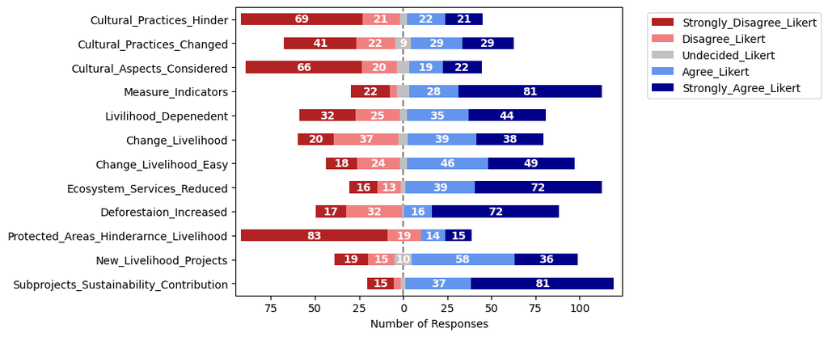

```python
%matplotlib inline
plot_likert.plot_counts(all_counts2, plot_likert.scales.agree,  plot_percentage=False, bar_labels=True, bar_labels_color="snow", colors=plot_likert.colors.default_with_darker_neutral)
plt.show()
```

7.3 Converting the Responses to Percentages The responses were converted to percentages

```python
all_counts3 = df3.apply(lambda col: col.value_counts(normalize=True, dropna=False).round(2))
```

```python
all_counts3
```

|  | Cultural_Practices_Hinder | Cultural_Practices_Changed | Cultural_Aspects_Considered | Measure_Indicators | Livilihood_Depenedent | Change_Livelihood | Change_Livelihood_Easy | Ecosystem_Services_Reduced | Deforestaion_Increased | Protected_Areas_Hinderarnce_Livelihood | New_Livelihood_Projects | Subprojects_Sustainability_Contribution |
| --- | --- | --- | --- | --- | --- | --- | --- | --- | --- | --- | --- | --- |
| Agree_Likert | 0.15 | 0.19 | 0.13 | 0.19 | 0.23 | 0.26 | 0.31 | 0.26 | 0.11 | 0.09 | 0.39 | 0.25 |
| Disagree_Likert | 0.14 | 0.15 | 0.13 | 0.03 | 0.17 | 0.25 | 0.16 | 0.09 | 0.21 | 0.13 | 0.10 | 0.03 |
| Strongly_Agree_Likert | 0.14 | 0.19 | 0.15 | 0.54 | 0.29 | 0.25 | 0.33 | 0.48 | 0.48 | 0.10 | 0.24 | 0.54 |
| Strongly_Disagree_Likert | 0.46 | 0.27 | 0.44 | 0.15 | 0.21 | 0.13 | 0.12 | 0.11 | 0.11 | 0.55 | 0.13 | 0.10 |
| Undecided_Likert | 0.03 | 0.06 | 0.05 | 0.05 | 0.03 | 0.03 | 0.03 | 0.02 | 0.01 | NaN | 0.07 | 0.02 |
| NaN | 0.09 | 0.13 | 0.11 | 0.05 | 0.07 | 0.07 | 0.06 | 0.05 | 0.08 | 0.13 | 0.08 | 0.07 |

7.3.1 Transposing the Dataframe Table Interchanging the rows and columns

```python
all_counts4 = all_counts3.head().T
```

```python
all_counts4
```

|  | Agree_Likert | Disagree_Likert | Strongly_Agree_Likert | Strongly_Disagree_Likert | Undecided_Likert |
| --- | --- | --- | --- | --- | --- |
| Cultural_Practices_Hinder | 0.15 | 0.14 | 0.14 | 0.46 | 0.03 |
| Cultural_Practices_Changed | 0.19 | 0.15 | 0.19 | 0.27 | 0.06 |
| Cultural_Aspects_Considered | 0.13 | 0.13 | 0.15 | 0.44 | 0.05 |
| Measure_Indicators | 0.19 | 0.03 | 0.54 | 0.15 | 0.05 |
| Livilihood_Depenedent | 0.23 | 0.17 | 0.29 | 0.21 | 0.03 |
| Change_Livelihood | 0.26 | 0.25 | 0.25 | 0.13 | 0.03 |
| Change_Livelihood_Easy | 0.31 | 0.16 | 0.33 | 0.12 | 0.03 |
| Ecosystem_Services_Reduced | 0.26 | 0.09 | 0.48 | 0.11 | 0.02 |
| Deforestaion_Increased | 0.11 | 0.21 | 0.48 | 0.11 | 0.01 |
| Protected_Areas_Hinderarnce_Livelihood | 0.09 | 0.13 | 0.10 | 0.55 | NaN |
| New_Livelihood_Projects | 0.39 | 0.10 | 0.24 | 0.13 | 0.07 |
| Subprojects_Sustainability_Contribution | 0.25 | 0.03 | 0.54 | 0.10 | 0.02 |

7.3.2 Changing the Order of Columns The order of columns was changed

```python
all_counts5 = all_counts4.iloc[:, [3, 1, 4, 0, 2]]
```

```python
all_counts5
```

|  | Strongly_Disagree_Likert | Disagree_Likert | Undecided_Likert | Agree_Likert | Strongly_Agree_Likert |
| --- | --- | --- | --- | --- | --- |
| Cultural_Practices_Hinder | 0.46 | 0.14 | 0.03 | 0.15 | 0.14 |
| Cultural_Practices_Changed | 0.27 | 0.15 | 0.06 | 0.19 | 0.19 |
| Cultural_Aspects_Considered | 0.44 | 0.13 | 0.05 | 0.13 | 0.15 |
| Measure_Indicators | 0.15 | 0.03 | 0.05 | 0.19 | 0.54 |
| Livilihood_Depenedent | 0.21 | 0.17 | 0.03 | 0.23 | 0.29 |
| Change_Livelihood | 0.13 | 0.25 | 0.03 | 0.26 | 0.25 |
| Change_Livelihood_Easy | 0.12 | 0.16 | 0.03 | 0.31 | 0.33 |
| Ecosystem_Services_Reduced | 0.11 | 0.09 | 0.02 | 0.26 | 0.48 |
| Deforestaion_Increased | 0.11 | 0.21 | 0.01 | 0.11 | 0.48 |
| Protected_Areas_Hinderarnce_Livelihood | 0.55 | 0.13 | NaN | 0.09 | 0.10 |
| New_Livelihood_Projects | 0.13 | 0.10 | 0.07 | 0.39 | 0.24 |
| Subprojects_Sustainability_Contribution | 0.10 | 0.03 | 0.02 | 0.25 | 0.54 |

7.3.3 Visualising the Results The results are visualised as pecentages

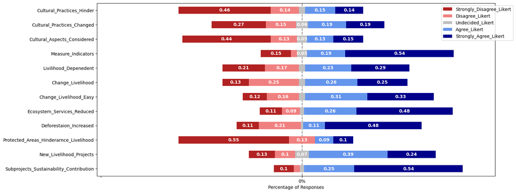

```python
%matplotlib inline
plot_likert.plot_counts(all_counts5, plot_likert.scales.agree,  plot_percentage=True, figsize=(16, 7), bar_labels=True, bar_labels_color="snow", colors=plot_likert.colors.default_with_darker_neutral)
plt.show()
```

8.0 Defined or Responses with Choices The responses that had choices other than those with a likert scale were grouped in a pandas dataframe looking the following question:

```
'50. What is the main purpose of landscapes (Forests, Water Bodies, Wetlandsâ€¦ etc.) in your livelihood?': 'Purpose_Landscape',
'52. How is your connection to nature like?': 'Connection_Nature',
'54. How long have you worked on this livelihood project?': 'Livelihood_Project',
'64. Which livelihood is a major contributor to landscape transformation?': 'Contributor_Landscape_Transformation',
'66. Which type of landscape do you depend on much for a livelihood?': 'Landscape_Depended_Livelihood'
```

```python
df4=df2.drop(df2.columns[[0,1,2,3,4,5,6,7,8,9,10,11,12,14,16,18,19,20,21,22,23,24,25,26,28,30,31,32,33,34]], axis = 1)
```

```python
df4
```

|  | Purpose_Landscape | Connection_Nature | Livelihood_Project | Contributor_Landscape_Transformation | Landscape_Depended_Livelihood |
| --- | --- | --- | --- | --- | --- |
| 0 | Nature_Protection_Purpose | Psychological_Connection,Material_Connection | 3to4Years_Long | Wood_Extraction | Agriculture_Areas_Dependent |
| 1 | Nature_Protection_Purpose | Philosophical_Connection,Psychological_Connection | Greaterthan9Years_Long | Land_Agriculture | Wetlands_Dependent |
| 2 | Nature_Protection_Purpose,Ancestral_Shrines_Purpose | Experiential_Connection | 5to6Years_Long | Wood_Extraction | Agriculture_Areas_Dependent,Wetlands_Dependent |
| 3 | Source_Income_Purpose | Material_Connection | Greaterthan9Years_Long | Land_Agriculture | Agriculture_Areas_Dependent |
| 4 | Nature_Protection_Purpose | Philosophical_Connection,Psychological_Connection | 5to6Years_Long | Land_Agriculture | Forest_Dependent,Wetlands_Dependent |
| ... | ... | ... | ... | ... | ... |
| 145 | NaN | NaN | NaN | NaN | NaN |
| 146 | Nature_Protection_Purpose | Material_Connection | 3to4Years_Long | Wood_Extraction | Agriculture_Areas_Dependent |
| 147 | NaN | Material_Connection | 3to4Years_Long | Wood_Extraction | Agriculture_Areas_Dependent |
| 148 | Nature_Protection_Purpose | Material_Connection | 3to4Years_Long | Uncontrolled_Fires | Agriculture_Areas_Dependent |
| 149 | Nature_Protection_Purpose | Material_Connection | Greaterthan9Years_Long | Uncontrolled_Fires | Wetlands_Dependent |

150 rows Ã— 5 columns

8.1 The Purpose of Landscape to People

```python
PL = df4['Purpose_Landscape'].value_counts(dropna=False)
PL_P = (df4['Purpose_Landscape'].value_counts(normalize=True, dropna=False).round(2))
```

```python
PL_P
```

```
Purpose_Landscape
Nature_Protection_Purpose                              0.62
NaN                                                    0.22
Source_Income_Purpose                                  0.11
Nature_Protection_Purpose,Other_Purpose                0.01
Nature_Protection_Purpose,Ancestral_Shrines_Purpose    0.01
Source_Income_Purpose,Nature_Protection_Purpose        0.01
Nature_Protection_Purpose,Source_Income_Purpose        0.01
Source_Income_Purpose,Other_Purpose                    0.01
No_Idea_Purpose                                        0.01
Other_Purpose                                          0.01
Name: proportion, dtype: float64
```

```python
df_PL = pd.DataFrame(PL)
```

```python
df_PL
```

| Purpose_Landscape | count |
| --- | --- |
| Nature_Protection_Purpose | 93 |
| NaN | 33 |
| Source_Income_Purpose | 16 |
| Nature_Protection_Purpose,Other_Purpose | 2 |
| Nature_Protection_Purpose,Ancestral_Shrines_Purpose | 1 |
| Source_Income_Purpose,Nature_Protection_Purpose | 1 |
| Nature_Protection_Purpose,Source_Income_Purpose | 1 |
| Source_Income_Purpose,Other_Purpose | 1 |
| No_Idea_Purpose | 1 |
| Other_Purpose | 1 |

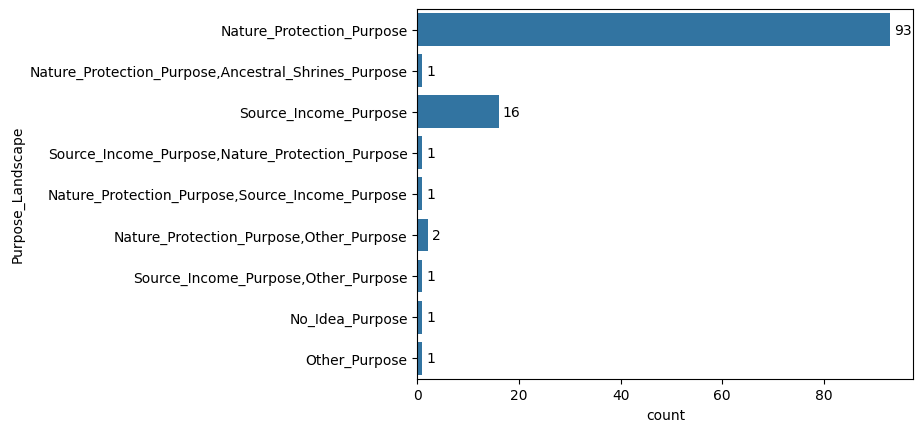

```python
ax = sns.countplot(df4["Purpose_Landscape"])
for container in ax.containers:
    ax.bar_label(container, fmt="%.0f", label_type="edge", padding=3)
plt.show()
```

8.2 The Connection of Nature to People

```python
CN = df4['Connection_Nature'].value_counts(dropna=False)
CN_P = (df4['Connection_Nature'].value_counts(normalize=True, dropna=False).round(2))
```

```python
CN_P
```

```
Connection_Nature
Material_Connection                                  0.82
NaN                                                  0.09
Other_Connection                                     0.04
Experiential_Connection                              0.01
Philosophical_Connection,Psychological_Connection    0.01
Psychological_Connection,Material_Connection         0.01
Psychological_Connection                             0.01
Philosophical_Connection                             0.01
Experiential_Connection,Material_Connection          0.01
Name: proportion, dtype: float64
```

```python
df_CN = pd.DataFrame(CN)
```

```python
df_CN
```

| Connection_Nature | count |
| --- | --- |
| Material_Connection | 123 |
| NaN | 13 |
| Other_Connection | 6 |
| Experiential_Connection | 2 |
| Philosophical_Connection,Psychological_Connection | 2 |
| Psychological_Connection,Material_Connection | 1 |
| Psychological_Connection | 1 |
| Philosophical_Connection | 1 |
| Experiential_Connection,Material_Connection | 1 |

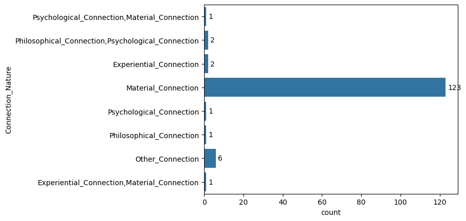

```python
ax = sns.countplot(df4["Connection_Nature"])
for container in ax.containers:
    ax.bar_label(container, fmt="%.0f", label_type="edge", padding=3)
plt.show()
```

```python
agreement_levels = ["Material_Connection", "Other_Connection"]
CN_R = df2[df2["Connection_Nature"].isin(agreement_levels)]
CN_R1 = CN_R.drop(CN_R.columns[[0,1,2,3,4,6,7,8,9,10,11,12,13,14,17,18,19,20,21,22,23,24,25,26,27,28,29,30,31,32,33,34]], axis = 1)
CN_R1grouped = CN_R1.groupby('Name_Main_Project')['Connection_Nature']
CN_R1
```

|  | Name_Main_Project | Connection_Nature | Connection_Nature_Reasons |
| --- | --- | --- | --- |
| 3 | TRALARD_LNM | Material_Connection | To use some of them for income |
| 6 | TRALARD_LNM | Material_Connection | They are a source of income and for the future generation to see them |
| 7 | TRALARD_LNM | Material_Connection | Sourve of income |
| 8 | TRALARD_LNM | Material_Connection | It is a source of income |
| 10 | TRALARD_LNM | Material_Connection | Thats were we get income as welll as fro example cattle we use it for cultivating |
| ... | ... | ... | ... |
| 144 | PIN_WESTERN | Material_Connection | NaN |
| 146 | PIN_WESTERN | Material_Connection | NaN |
| 147 | PIN_WESTERN | Material_Connection | NaN |
| 148 | PIN_WESTERN | Material_Connection | NaN |
| 149 | SCReBS_WESTERN | Material_Connection | NaN |

129 rows Ã— 3 columns

```python
lemmatizer=WordNetLemmatizer()
stop_words = set(stopwords.words('english'))
for index, row in CN_R1.iterrows():
    CN_R1_filter_sentence = []
    CN_R1_sentence = row["Connection_Nature_Reasons"]
    if pd.isnull(CN_R1_sentence):
       continue
    CN_R1_sentence_cleaned = re.sub(r'[^\w\s]','',CN_R1_sentence)
    CN_R1_words = nltk.word_tokenize(CN_R1_sentence_cleaned)
    CN_R1_words = [lemmatizer.lemmatize(w) for w in CN_R1_words if w.lower() not in stop_words]
    CN_R1_filter_sentence.extend(CN_R1_words)
    print(CN_R1_filter_sentence)
```

```
['use', 'income']
['source', 'income', 'future', 'generation', 'see']
['Sourve', 'income']
['source', 'income']
['Thats', 'get', 'income', 'welll', 'fro', 'example', 'cattle', 'use', 'cultivating']
['help', 'u', 'source', 'income', 'vorm', 'meat', 'animal', 'tree', 'rain', 'come', 'protected']
['need', 'keep', 'fish', 'vor', 'instanec', 'fish', 'pond', 'get', 'extinct']
['one', 'lokk', 'daily', 'basis']
['source', 'livelihood']
['need', 'protect', 'nature', 'instatance', 'cutting', 'tree', 'river', 'dry', 'distruction', 'animal', 'river']
['answer']
['purpose', 'furtute', 'meet', 'need']
['source', 'invome']
['tree', 'help', 'u', 'bring', 'rqinfall']
['Source', 'invome']
['harvest', 'atvthe', 'right', 'time', 'prevent', 'management', 'naturalnresources']
['takingvcare']
['Sourc', 'e', 'income']
['Source', 'income']
['bring', 'development', 'tourims']
['icome']
['natutal', 'resource', 'like', 'tree', 'give', 'shade', 'medice', 'anf', 'also', 'getvfishce']
['Like', 'water', 'source', 'life', 'tres', 'source', 'fresh', 'water']
['source', 'income']
['source', 'ofbincomr']
['zawa', 'peolle', 'onee', 'conenected', 'thr', 'look', 'agter', 'thrm']
['geyvare', 'source', 'incone', 'tourism']
['answer']
['helo', 'u', 'beeing', 'source', 'og', 'food', 'well', 'water']
['tres', 'arev', 'procted', 'lead', 'rainfall', 'area']
['Theyvarev', 'avsource', 'ofblivelihood']
['Somehow', 'protect']
['Tgey', 'help', 'lot', 'thing', 'air', 'breath']
['orotect', 'u', 'instaance', 'tree', 'protectbfromnwind', 'theybbring', 'freshbair', 'well', 'preveny', 'river', 'fron', 'drying']
['Thats', 'get', 'honey', 'bee', 'hive', 'u', 'loot', 'money']
['Thats', 'get', 'free', 'air', 'traditional', 'medicine', 'anc', 'livelihood', 'depend', 'natural', 'resource']
['instance', 'fish', 'caught', 'brings', 'income', 'source', 'food', 'well', 'tree', 'bring', 'rainfall', 'indircetly']
[]
```

8.3 The Length of Existence of the Livelihood Project

```python
LP = df4['Livelihood_Project'].value_counts(dropna=False)
LP_P = (df4['Livelihood_Project'].value_counts(normalize=True, dropna=False).round(2))
```

```python
LP_P
```

```
Livelihood_Project
3to4Years_Long            0.42
5to6Years_Long            0.33
NaN                       0.08
Lessthan2Years_Long       0.06
7to8Years_Long            0.06
Greaterthan9Years_Long    0.05
Name: proportion, dtype: float64
```

```python
df_LP = pd.DataFrame(LP)
```

```python
df_LP
```

| Livelihood_Project | count |
| --- | --- |
| 3to4Years_Long | 63 |
| 5to6Years_Long | 50 |
| NaN | 12 |
| Lessthan2Years_Long | 9 |
| 7to8Years_Long | 9 |
| Greaterthan9Years_Long | 7 |

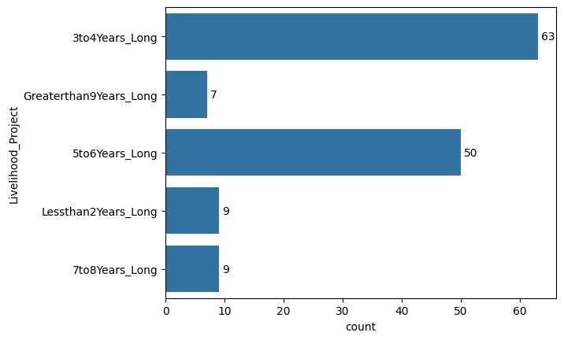

```python
ax = sns.countplot(df4["Livelihood_Project"])
for container in ax.containers:
    ax.bar_label(container, fmt="%.0f", label_type="edge", padding=3)
plt.show()
```

8.4 Major Contributor to Landscape Transformation

```python
CLT = df4['Contributor_Landscape_Transformation'].value_counts(dropna=False)
CLT_P = (df4['Contributor_Landscape_Transformation'].value_counts(normalize=True, dropna=False).round(2))
```

```python
CLT_P
```

```
Contributor_Landscape_Transformation
Uncontrolled_Fires                     0.33
Land_Agriculture                       0.29
Wood_Extraction                        0.26
NaN                                    0.09
Uncontrolled_Grazing                   0.01
Uncontrolled_Fires,Land_Agriculture    0.01
Other                                  0.01
Name: proportion, dtype: float64
```

```python
df_CLT = pd.DataFrame(CLT)
```

```python
df_CLT
```

| Contributor_Landscape_Transformation | count |
| --- | --- |
| Uncontrolled_Fires | 49 |
| Land_Agriculture | 44 |
| Wood_Extraction | 39 |
| NaN | 14 |
| Uncontrolled_Grazing | 2 |
| Uncontrolled_Fires,Land_Agriculture | 1 |
| Other | 1 |

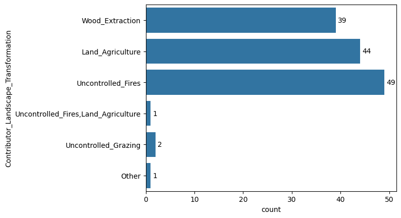

```python
ax = sns.countplot(df4["Contributor_Landscape_Transformation"])
for container in ax.containers:
    ax.bar_label(container, fmt="%.0f", label_type="edge", padding=3)
plt.show()
```

```python
agreement_levels = ["Wood_Extration", "Land_Agriculture","Uncontrolled_Fires"]
CLT_R = df2[df2["Contributor_Landscape_Transformation"].isin(agreement_levels)]
CLT_R1 = CN_R.drop(CLT_R.columns[[0,1,2,3,4,6,7,8,9,10,11,12,13,14,15,16,17,18,19,20,21,22,23,24,25,26,29,30,31,32,33,34]], axis = 1)
CLT_R1grouped = CLT_R1.groupby('Name_Main_Project')['Contributor_Landscape_Transformation']
CLT_R1
```

|  | Name_Main_Project | Contributor_Landscape_Transformation | Contributor_Landscape_Transformation_Reasons |
| --- | --- | --- | --- |
| 3 | TRALARD_LNM | Land_Agriculture | Because it requires a huge land than the others the making chaocoal |
| 6 | TRALARD_LNM | Wood_Extraction | The burningbof chaorcaoal give smoke that destroys the ozone layer as well as it bring acidic rains |
| 7 | TRALARD_LNM | Land_Agriculture | There agricukture activitie for food |
| 8 | TRALARD_LNM | Wood_Extraction | There is no electrity huge demand for energy |
| 10 | TRALARD_LNM | Wood_Extraction | The charcaol purposes is bad because the land is left bare unlike for agriculture cutting which is rrplaced with othr plants |
| ... | ... | ... | ... |
| 144 | PIN_WESTERN | Uncontrolled_Fires | The trees when they get burnt they dry and thats the reason we have less rainfall |
| 146 | PIN_WESTERN | Wood_Extraction | They use chitemen system of just cuttingbtrees for choarcaol |
| 147 | PIN_WESTERN | Wood_Extraction | The trees and cut and make charcoal the do bnot grow |
| 148 | PIN_WESTERN | Uncontrolled_Fires | It distroys everythin on it ways |
| 149 | SCReBS_WESTERN | Uncontrolled_Fires | It diatroys everything on its path |

129 rows Ã— 3 columns

```python
lemmatizer=WordNetLemmatizer()
stop_words = set(stopwords.words('english'))
for index, row in CLT_R1.iterrows():
    CLT_R1_filter_sentence = []
    CLT_R1_sentence = row["Contributor_Landscape_Transformation_Reasons"]
    if pd.isnull(CLT_R1_sentence):
       continue
    CLT_R1_sentence_cleaned = re.sub(r'[^\w\s]','',CLT_R1_sentence)
    CLT_R1_words = nltk.word_tokenize(CLT_R1_sentence_cleaned)
    CLT_R1_words = [lemmatizer.lemmatize(w) for w in CLT_R1_words if w.lower() not in stop_words]
    CLT_R1_filter_sentence.extend(CLT_R1_words)
    print(CLT_R1_filter_sentence)
```

```
['requires', 'huge', 'land', 'others', 'making', 'chaocoal']
['burningbof', 'chaorcaoal', 'give', 'smoke', 'destroys', 'ozone', 'layer', 'well', 'bring', 'acidic', 'rain']
['agricukture', 'activitie', 'food']
['electrity', 'huge', 'demand', 'energy']
['charcaol', 'purpose', 'bad', 'land', 'left', 'bare', 'unlike', 'agriculture', 'cutting', 'rrplaced', 'othr', 'plant']
['cultivation', 'cassava', 'requires', 'always', 'barren', 'land', 'never', 'beenn', 'cultivated', 'grow', 'well', 'crop', 'sa', 'bean', 'vegetable', 'maize', 'reduce', 'deforesttio']
['burn', 'tree', 'shoot']
['Chitemene', 'system', 'cjltivation', 'lead', 'deforestation', 'others']
['source', 'food', 'people', 'area']
['Thats', 'get', 'livelihood']
['source', 'income']
['time', 'cut', 'tree', 'even', 'want', 'cultivate', 'well', 'burining', 'kill', 'animal', 'tgat', 'neccesary', 'making', 'soil', 'fertile']
['Buring', 'cam', 'desyroy', 'thrv', 'product', 'crop', 'thst', 'arevin', 'thrv', 'soil']
['cutiing', 'downbof', 'treed', 'change', 'landscape']
['cutting', 'destriy', 'much', 'regrowth']
['u', 'income', 'huge', 'area', 'tree', 'cutt']
['commercial', 'thatvclear', 'huge', 'chuck', 'land']
['Source', 'invome']
['forming', 'og', 'food', 'crop']
['source', 'income']
['people', 'plant', 'huge', 'area', 'land', 'livelihood']
['animal', 'food', 'well', 'thr', 'tree', 'woukd', 'dry']
['income', 'food', 'crop']
['farming', 'activis', 'brings', 'income']
['soil', 'get', 'degraded', 'movebto', 'another', 'portion', 'land']
['source', 'income']
['peoplr', 'burn', 'argricukturr', 'aeea', 'people', 'lookingbfot', 'rat', 'Inaddition', 'burn', 'food', 'crop', 'due', 'serchbof', 'rat']
['cutting', 'tres', 'disyroy', 'cause', 'fot', 'liveliood']
['tree', 'challenge', 'growung', 'burned']
['people', 'whoncutt', 'tree', 'choarcaol', 'distroyvthrm', 'itbisndifficuktbfot', 'regenetation']
['Sourxe', 'income']
['tres', 'dry', 'burnt']
['fire', 'cause', 'lot', 'danage', 'bidiversity', 'ell', 'plant']
['tee', 'get', 'burn', 'reducinh', 'regeration', 'well', 'tge', 'fertility', 'theb', 'soil']
['tres', 'getcdistroyed', 'theyvare', 'burnt', 'andnit', 'digfivukt', 'regenerate']
['cuting', 'tres', 'chaocaol', 'prevenys', 'regeneration']
['cutingv', 'fot', 'chaocal', 'requires', 'huge', 'land', 'comoaredv', 'farm', 'onrl', 'one', 'partionnof', 'land']
['small', 'bidiversity', 'distroyed', 'fire']
['Burningbdistroys', 'tres']
['fire', 'bur', 'tree', 'dry']
```

[output cut: 60 more lines]

```
['Fire', 'burn', 'whole', 'area']
['Burning', 'kill', 'lot', 'thing', 'biodiversity']
['tree', 'cut', 'lot', 'thus', 'distructs', 'lot']
['Whenthe', 'tree', 'cutt', 'grow']
['cutting', 'tree', 'bring', 'drought']
['tree', 'cut', 'area', 'possing', 'treat', 'strong', 'wind']
['fains', 'watwr', 'flow', 'due', 'lack', 'tree', 'block']
['leaf', 'xlimate', 'xue', 'lack', 'tres']
['animal', 'graz', 'thus', 'make', 'move', 'long', 'idtance', 'sto', 'find', 'pasture']
['rainfall', 'back', 'green', 'vegitation', 'thus', 'burt', 'less', 'rainfall']
['tree', 'get', 'burnt', 'dry', 'thats', 'reason', 'less', 'rainfall']
['use', 'chitemen', 'system', 'cuttingbtrees', 'choarcaol']
['tree', 'cut', 'make', 'charcoal', 'bnot', 'grow']
['distroys', 'everythin', 'way']
['diatroys', 'everything', 'path']
```

8.5 The Landscape depenede on for Livelihood

```python
LDL = df4['Landscape_Depended_Livelihood'].value_counts(dropna=False)
LDL_P = (df4['Landscape_Depended_Livelihood'].value_counts(normalize=True, dropna=False).round(2))
```

```python
LDL_P
```

```
Landscape_Depended_Livelihood
Agriculture_Areas_Dependent                       0.61
Wetlands_Dependent                                0.17
Forest_Dependent                                  0.09
NaN                                               0.09
Wetlands_Dependent,Forest_Dependent               0.03
Agriculture_Areas_Dependent,Wetlands_Dependent    0.01
Forest_Dependent,Wetlands_Dependent               0.01
Wetlands_Dependent,Agriculture_Areas_Dependent    0.01
Name: proportion, dtype: float64
```

```python
df_LDL = pd.DataFrame(LDL)
```

```python
df_LDL
```

| Landscape_Depended_Livelihood | count |
| --- | --- |
| Agriculture_Areas_Dependent | 92 |
| Wetlands_Dependent | 25 |
| Forest_Dependent | 13 |
| NaN | 13 |
| Wetlands_Dependent,Forest_Dependent | 4 |
| Agriculture_Areas_Dependent,Wetlands_Dependent | 1 |
| Forest_Dependent,Wetlands_Dependent | 1 |
| Wetlands_Dependent,Agriculture_Areas_Dependent | 1 |

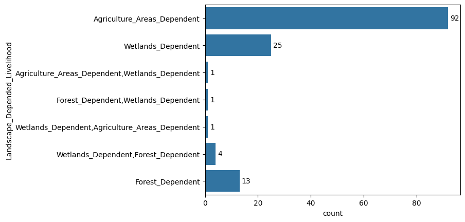

```python
ax = sns.countplot(df4["Landscape_Depended_Livelihood"])
for container in ax.containers:
    ax.bar_label(container, fmt="%.0f", label_type="edge", padding=3)
plt.show()
```

```python
agreement_levels = ["Agriculture_Areas_Dependent", "Wetland_Depenedent","Forest_Dependent"]
LDL_R = df2[df2["Landscape_Depended_Livelihood"].isin(agreement_levels)]
LDL_R1 = LDL_R.drop(LDL_R.columns[[0,1,2,3,4,6,7,8,9,10,11,12,13,14,15,16,17,18,19,20,21,22,23,24,25,26,27,28,31,32,33,34]], axis = 1)
LDL_R1grouped = LDL_R1.groupby('Name_Main_Project')['Landscape_Depended_Livelihood']
LDL_R1
```

|  | Name_Main_Project | Landscape_Depended_Livelihood | Landscape_Depeneded_Livelihood_Reasons |
| --- | --- | --- | --- |
| 0 | TRALARD_LNM | Agriculture_Areas_Dependent | He caltivates a large area of land so that some crops can be sold for a livelihood |
| 3 | TRALARD_LNM | Agriculture_Areas_Dependent | Food is the main source of livelihood thus without it there is no way to earn a living |
| 5 | TRALARD_LNM | Agriculture_Areas_Dependent | There is a source of income as well as food for consuption |
| 6 | TRALARD_LNM | Agriculture_Areas_Dependent | There farming helps in sourcr of food |
| 8 | TRALARD_LNM | Agriculture_Areas_Dependent | Thats were a source of income |
| ... | ... | ... | ... |
| 143 | SCReBS_WESTERN | Agriculture_Areas_Dependent | We are farmers |
| 144 | PIN_WESTERN | Agriculture_Areas_Dependent | Thats is where we get our crops from |
| 146 | PIN_WESTERN | Agriculture_Areas_Dependent | We farmers |
| 147 | PIN_WESTERN | Agriculture_Areas_Dependent | Thats where we get food and money |
| 148 | PIN_WESTERN | Agriculture_Areas_Dependent | That were our food crops are found |

105 rows Ã— 3 columns

```python
lemmatizer=WordNetLemmatizer()
stop_words = set(stopwords.words('english'))
for index, row in LDL_R1.iterrows():
    LDL_R1_filter_sentence = []
    LDL_R1_sentence = row["Landscape_Depeneded_Livelihood_Reasons"]
    if pd.isnull(LDL_R1_sentence):
       continue
    LDL_R1_sentence_cleaned = re.sub(r'[^\w\s]','',LDL_R1_sentence)
    LDL_R1_words = nltk.word_tokenize(LDL_R1_sentence_cleaned)
    LDL_R1_words = [lemmatizer.lemmatize(w) for w in LDL_R1_words if w.lower() not in stop_words]
    LDL_R1_filter_sentence.extend(LDL_R1_words)
    print(LDL_R1_filter_sentence)
```

```
['caltivates', 'large', 'area', 'land', 'crop', 'sold', 'livelihood']
['Food', 'main', 'source', 'livelihood', 'thus', 'without', 'way', 'earn', 'living']
['source', 'income', 'well', 'food', 'consuption']
['farming', 'help', 'sourcr', 'food']
['Thats', 'source', 'income']
['source', 'livelihood']
['income', 'come', 'living']
['help', 'u', 'cultivate', 'cassava', 'maize', 'mu', 'h', 'fidhing', 'activity']
['farming', 'obtain', 'foood', 'co', 'su3ption', 'household', 'lkevl']
['food', 'security', 'come']
['tree', 'bring', 'rainfall', 'area', 'compared', 'area']
['source', 'income']
['majority', 'people', 'cutivate', 'land', 'livelohood', 'depending', 'buying', 'shop']
['Thats', 'whats', 'common', 'within', 'area']
['source', 'traditional', 'medicine']
['source', 'food', 'crop', 'income']
['use', 'cultivation']
['Sourcr', 'income']
['mostly', 'farmer']
['Thats', 'isbtheb', 'source', 'income', 'livelihood']
['food', 'croos']
['isbwhere', 'food', 'croos', 'come']
['Thats', 'source', 'food', 'croos', 'well', 'income']
['Thats', 'grow', 'crop', 'livelihood']
['livelihood', 'farming', 'main', 'stay']
['provode', 'resourcesvfor', 'peole', 'interms', 'wood']
['obtain', 'food', 'crop', 'tgatv', 'assit', 'u', 'livelihood']
['source', 'crop', 'food']
['Thats', 'grow', 'croos', 'livewlihoods']
['inhave', 'portionnof', 'land', 'ibwill', 'cultivating', 'one', 'area', 'thusbbee', 'need', 'tree', 'thus', 'cutting', 'tree']
['Thats', 'getvfood', 'foodbproductsbfor', 'livelihood']
['answer']
['crop', 'income', 'come']
['Thats', 'getvfood', 'thatvwe', 'eatv']
['Source', 'livelihood']
['income', 'andfood', 'croos', 'come']
['therevare', 'tree', 'rain', 'much', 'well', 'thebsoil', 'feryile']
['Thats', 'get', 'food', 'crop', 'survival']
['Eqch', 'qnd', 'eveey', 'individend']
['source', 'mashrooms', 'catapilkars', 'forest', 'protected', 'well', 'working', 'honery', 'officer']
```

[output cut: 48 more lines]

```
['get', 'food', 'eating']
['Thats', 'grow', 'crop']
['Thats', 'get', 'food']
['Thats', 'food', 'crop', 'come']
['Thats', 'food', 'crop', 'come']
['Thats', 'get', 'food', 'crop']
['Thats', 'get', 'food', 'crop']
['farmer', 'rice']
['get', 'oir', 'food', 'crop']
['Thats', 'get', 'food']
['farmer']
['Thats', 'get', 'crop']
['farmer']
['Thats', 'get', 'food', 'money']
['food', 'crop', 'found']
```

8.6 Explanation to Choices It gives an explanation to the choice selected that is not among the choices that were provided in the list of the questionnaire

```python
df5=df2.drop(df2.columns[[0,1,2,3,4,5,6,7,8,9,10,11,12,13,14,15,16,17,18,19,20,21,22,23,24,25,26,27,28,29,30]], axis = 1)
```

```python
df5
```

|  | Purpose_Landscape_Specific | Connection_Nature_Specific | Contributor_Landscape_Transformation_Specific | Landscape_Depended_Livelihood_Specific |
| --- | --- | --- | --- | --- |
| 0 | NaN | NaN | NaN | NaN |
| 1 | NaN | NaN | NaN | NaN |
| 2 | NaN | NaN | NaN | NaN |
| 3 | NaN | NaN | NaN | NaN |
| 4 | Only the protection nature the others are not important | NaN | NaN | NaN |
| ... | ... | ... | ... | ... |
| 145 | NaN | NaN | NaN | NaN |
| 146 | NaN | NaN | NaN | NaN |
| 147 | NaN | NaN | NaN | NaN |
| 148 | NaN | NaN | NaN | NaN |
| 149 | NaN | NaN | NaN | NaN |

150 rows Ã— 4 columns

```python
lemmatizer=WordNetLemmatizer()
stop_words = set(stopwords.words('english'))
for index, row in df5.iterrows():
    PL_RS1_filter_sentence = []
    PL_RS1_sentence = row["Purpose_Landscape_Specific"]
    if pd.isnull(PL_RS1_sentence):
       continue
    PL_RS1_sentence_cleaned = re.sub(r'[^\w\s]','',PL_RS1_sentence)
    PL_RS1_words = nltk.word_tokenize(PL_RS1_sentence_cleaned)
    PL_RS1_words = [lemmatizer.lemmatize(w) for w in PL_RS1_words if w.lower() not in stop_words]
    PL_RS1_filter_sentence.extend(PL_RS1_words)
    print(PL_RS1_filter_sentence)
```

```
['protection', 'nature', 'others', 'important']
['fire', 'burn', 'thr', 'biodiversitity', 'helo', 'environmental', 'procrss']
['torist', 'bring', 'invome', 'view', 'thr', 'animal']
['source', 'income', 'tourism']
```

```python
lemmatizer=WordNetLemmatizer()
stop_words = set(stopwords.words('english'))
for index, row in df5.iterrows():
    CN_RS1_filter_sentence = []
    CN_RS1_sentence = row["Connection_Nature_Specific"]
    if pd.isnull(CN_RS1_sentence):
       continue
    CN_RS1_sentence_cleaned = re.sub(r'[^\w\s]','',CN_RS1_sentence)
    CN_RS1_words = nltk.word_tokenize(CN_RS1_sentence_cleaned)
    CN_RS1_words = [lemmatizer.lemmatize(w) for w in CN_RS1_words if w.lower() not in stop_words]
    CN_RS1_filter_sentence.extend(CN_RS1_words)
    print(CN_RS1_filter_sentence)
```

```
['Taking', 'care', 'nature', 'destroying']
['Taking', 'care', 'nature']
['Source', 'good', 'air', 'food', 'prodicts']
['related']
['Protection', 'tree']
['Taking', 'care', 'ov', 'animal']
```

```python
lemmatizer=WordNetLemmatizer()
stop_words = set(stopwords.words('english'))
for index, row in df5.iterrows():
    CLT_RS1_filter_sentence = []
    CLT_RS1_sentence = row["Contributor_Landscape_Transformation_Specific"]
    if pd.isnull(CLT_RS1_sentence):
       continue
    CLT_RS1_sentence_cleaned = re.sub(r'[^\w\s]','',CLT_RS1_sentence)
    CLT_RS1_words = nltk.word_tokenize(CLT_RS1_sentence_cleaned)
    CLT_RS1_words = [lemmatizer.lemmatize(w) for w in CLT_RS1_words if w.lower() not in stop_words]
    CLT_RS1_filter_sentence.extend(CLT_RS1_words)
    print(CLT_RS1_filter_sentence)
```

```
['Cutting', 'tree', 'sale']
```

```python
lemmatizer=WordNetLemmatizer()
stop_words = set(stopwords.words('english'))
for index, row in df5.iterrows():
    LDL_RS1_filter_sentence = []
    LDL_RS1_sentence = row["Landscape_Depended_Livelihood_Specific"]
    if pd.isnull(LDL_RS1_sentence):
       continue
    LDL_RS1_sentence_cleaned = re.sub(r'[^\w\s]','',LDL_RS1_sentence)
    LDL_RS1_words = nltk.word_tokenize(LDL_RS1_sentence_cleaned)
    LDL_RS1_words = [lemmatizer.lemmatize(w) for w in LDL_RS1_words if w.lower() not in stop_words]
    LDL_RS1_filter_sentence.extend(LDL_RS1_words)
    print(LDL_RS1_filter_sentence)
```

9.0 Description Statistics It gives a beckground to the study sites

```python
df6=df2.drop(df2.columns[[0,8,9,10,11,12,13,14,15,16,17,18,19,20,21,22,23,24,25,26,27,28,29,30,31,32,33,34]], axis = 1)
```

```python
df6
```

|  | Ward_Name | Sub_Project_name | Livelihood | Size | Name_Main_Project | Representing_Others | Number_Beneficiaries |
| --- | --- | --- | --- | --- | --- | --- | --- |
| 0 | Isamba ward | Isamba coperatives | Goat rearing | 8to12Lima_Size | TRALARD_LNM | yes | Greaterthan40People_Many |
| 1 | Isamba ward | Misenga cooperative multipurpose society | Goat rearing, Gardening, Fruit trees | Greaterthan16Lima_Size | TRALARD_LNM | yes | Greaterthan40People_Many |
| 2 | Isamba | Ninge Cooperative | Goat Rearing, Agricuture-cassava | Greaterthan16Lima_Size | TRALARD_LNM | yes | Greaterthan40People_Many |
| 3 | Isamba ward | Twikatene copperatives | Goat rearing and Fish farming and garden of vegitable and onnoind | Greaterthan16Lima_Size | TRALARD_LNM | yes | Greaterthan40People_Many |
| 4 | Isamba ward | Changwena women club | Chicken rearing ablnd an orchard | Lessthan4Lima_Size | TRALARD_LNM | NaN | 20to30People_Many |
| ... | ... | ... | ... | ... | ... | ... | ... |
| 145 | Yeta | NaN | Biochar | NaN | EbA_CENTRAL_MUCHINGA_LUAPULA | NaN | NaN |
| 146 | Yeta | Biochar | Gardening | Lessthan4Lima_Size | PIN_WESTERN | no | NaN |
| 147 | Yeta | Biochar | Gardening | Lessthan4Lima_Size | PIN_WESTERN | no | NaN |
| 148 | Yeta | B iochar | Gardenning | 8to12Lima_Size | PIN_WESTERN | no | NaN |
| 149 | Yeta ward | Piggery, fishponds and gardening | Fish ponds and piggery and gerdening | Lessthan4Lima_Size | SCReBS_WESTERN | yes | 10to20People_Many |

150 rows Ã— 7 columns

9.1 Main project Types This shows the number of questionaires that were administered to each project type

```python
MP = df6['Name_Main_Project'].value_counts(dropna=False)
```

```python
MP
```

```
Name_Main_Project
SCRiKA_LS                               41
TRALARD_LNM                             40
SCRALA_SOUTHERN_WESTERN_NORTHEN         29
SCReBS_WESTERN                          16
Ecosystem Conservation_NORTH_WESTERN     9
PIN_WESTERN                              5
EbA_CENTRAL_MUCHINGA_LUAPULA             4
NaN                                      3
Sustainable Luangwa_MAFINGA_DISTRICT     2
ZIFLP_EASTERN                            1
Name: count, dtype: int64
```

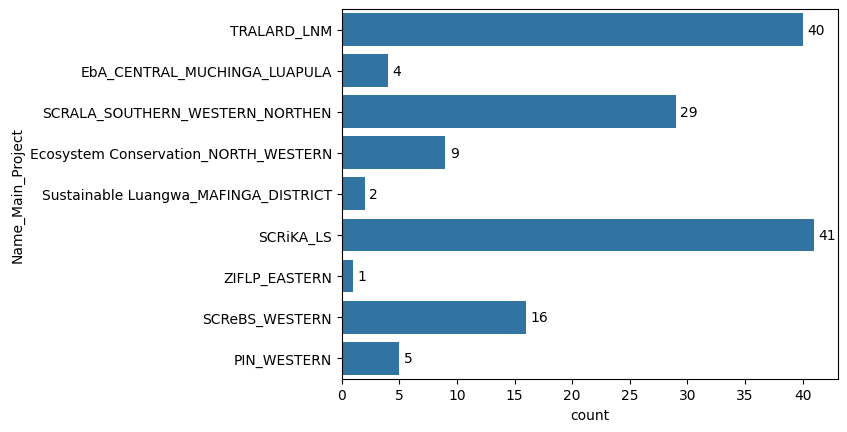

```python
ax = sns.countplot(df6["Name_Main_Project"])
for container in ax.containers:
    ax.bar_label(container, fmt="%.0f", label_type="edge", padding=3)
plt.show()
```

9.2 The Wards The wards that had respodents and their number

```python
WN = df6['Ward_Name'].value_counts(dropna=False)
```

```python
WN
```

```
Ward_Name
Mbila ward              14
Omba ward               13
NaN                      6
Makuya ward              6
Namwala central ward     6
                        ..
Kalobolewa ward          1
 mwanabuyu ward          1
Mwanbuyu warx            1
Yeta Ward                1
Yeta                     1
Name: count, Length: 63, dtype: int64
```

[figure not shown]

```python
ax = sns.countplot(df6["Ward_Name"])
for container in ax.containers:
    ax.bar_label(container, fmt="%.0f", label_type="edge", padding=3)
plt.show()
```

9.3 Number of beneficiaries It shows the number of households that benefited from the interviewees

```python
NB = df6['Number_Beneficiaries'].value_counts(dropna=False)
```

```python
NB
```

```
Number_Beneficiaries
Greaterthan40People_Many    40
NaN                         26
10to20People_Many           25
20to30People_Many           23
30to40People_Many           23
Lessthan10People_Many       13
Name: count, dtype: int64
```

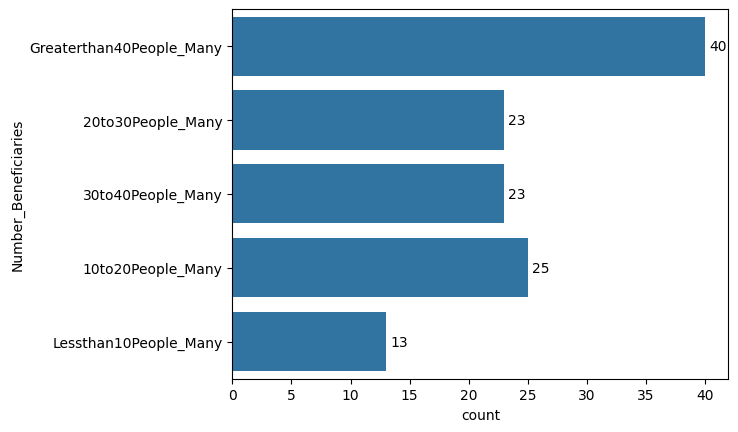

```python
ax = sns.countplot(df6["Number_Beneficiaries"])
for container in ax.containers:
    ax.bar_label(container, fmt="%.0f", label_type="edge", padding=3)
plt.show()
```

9.4 Size of Landscape

```python
SIZE = df6['Size'].value_counts(dropna=False)
```

```python
SIZE
```

```
Size
Lessthan4Lima_Size        48
Greaterthan16Lima_Size    40
NotApplicable_Size        30
4to8Lima_Size             13
NaN                       11
8to12Lima_Size             5
12to16Lima_Size            3
Name: count, dtype: int64
```

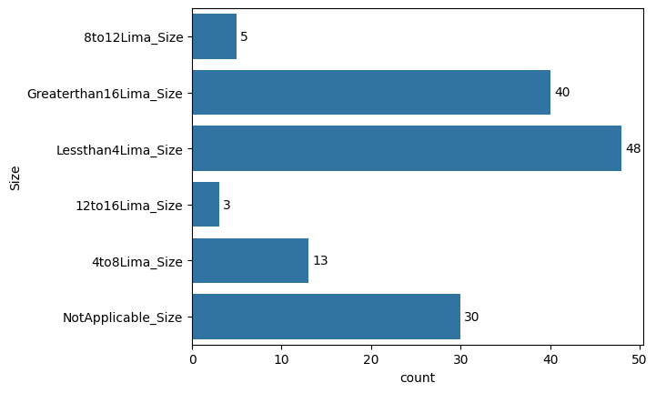

```python
ax = sns.countplot(df6["Size"])
for container in ax.containers:
    ax.bar_label(container, fmt="%.0f", label_type="edge", padding=3)
plt.show()
```

9.5 Represing Others It looks at those representing one house and more

```python
RO = df6['Representing_Others'].value_counts(dropna=False)
```

```python
RO
```

```
Representing_Others
yes    118
no      21
NaN     11
Name: count, dtype: int64
```

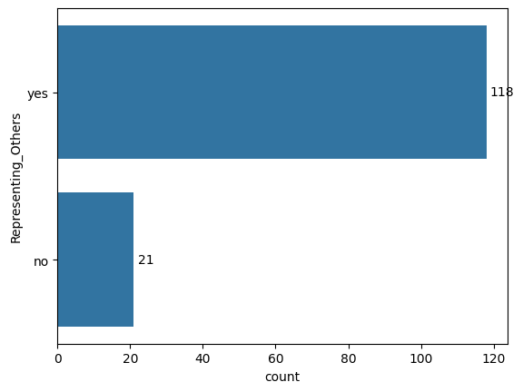

```python
ax = sns.countplot(df6["Representing_Others"])
for container in ax.containers:
    ax.bar_label(container, fmt="%.0f", label_type="edge", padding=3)
plt.show()
```

10.0 REASONS The pandas dataframe depicts columns for the reasons to the responses to the likert scales

```python
df7=df2.drop(df2.columns[[0,1,2,3,4,5,6,7,8,10,11,13,14,15,17,18,19,20,22,23,24,25,26,27,29,31,32,33,34]], axis = 1)
```

```python
df7
```

|  | Cultural_Practices_Hinder_Reason | Cultural_Aspects_Considered_Reasons | Connection_Nature_Reasons | Change_Livelihood_Easy_Reasons | Contributor_Landscape_Transformation_Reasons | Landscape_Depeneded_Livelihood_Reasons |
| --- | --- | --- | --- | --- | --- | --- |
| 0 | It has never happed before in his life time | There are no cultural history in the area | The animals can be used by the future general as well | If the SES are taken care of they can increase in number and bring income to him | The trees have been depleted and it has caused reduced rainfall | He caltivates a large area of land so that some crops can be sold for a livelihood |
| 1 | There is need to harvest tree when they have fully grown the same applies to biodiversity | There is need to have power in what he formulating so that there is ownership | How the animals they lead thems we can get examples from them | The SeS can be depleted thus there need to chang to agrivulture like goat rearing | Because i have to clear the land gor agriculture for to plant crops hence the the lsndscsoe change | Tje killing of fish is the source of income in thix area |
| 2 | There are no customary practices that hinder sustainable management | There are nop cultural aspects | Through experiments he gains nkowledge on the management of forest | Change is easier because he is the one who has deciededs to change | There would a reduction in the number of trees hence contributing to clinate chsnge | He depends much on agriculture the most than fish because the fish can be depleted |
| 3 | There are rotations made on the land when cultivation to ensure fetility of soil | At the time of getting the land for the project it commes with regulations | To use some of them for income | Because my livelihood would improve | Because it requires a huge land than the others the making chaocoal | Food is the main source of livelihood thus without it there is no way to earn a living |
| 4 | There is nothing | We only follow what the chiefs and the governmnet say | They are important in our lifes like trees they provide home for animals as well as food. In addition improve the soil textureove | There has been thongs like climate change affecting us tjus the thought to chnage | Because people cut down tree for farmimg but they never use the land but he would prefer they use a small portion to leave trees as a home of willd animals | The water is used for gardening and other things |
| ... | ... | ... | ... | ... | ... | ... |
| 145 | NaN | NaN | NaN | NaN | NaN | NaN |
| 146 | There is nothing | Only the indunas that send tye representative to learn and they accept the project in the community | NaN | The perwon can make a deciosn through lookig back what heor she done so as to make corrective measures | They use chitemen system of just cuttingbtrees for choarcaol | We farmers |
| 147 | There is nthing | There is nothing | NaN | As long as you aare commiteted | The trees and cut and make charcoal the do bnot grow | Thats where we get food and money |
| 148 | There is nothing | There is nothing | NaN | It is diffi jlt but as long as uou follow whag hou have been gaught uou can change | It distroys everythin on it ways | That were our food crops are found |
| 149 | There is nothing | We do not do it | NaN | As long sa i have the capacity to do so | It diatroys everything on its path | Thats where we plant maize and rice |

150 rows Ã— 6 columns

10.1 Reasons for Cultural Practices Hidering The reasons for cultural practices that hinder transfromation

```python
lemmatizer = WordNetLemmatizer()
CPH = df7['Cultural_Practices_Hinder_Reason'].str.lower().str.cat(sep=' ')
CPH_words = nltk.tokenize.word_tokenize(CPH)
CPH_filtered_tokens = [word for word in CPH_words if len(CPH_words) >= 4]
CPH_lemmatized_words = [lemmatizer.lemmatize(word) for word in CPH_filtered_tokens]
CPH_token_counts = Counter(CPH_lemmatized_words)
CPH_columns = pd.DataFrame(CPH_token_counts.most_common(27),
columns = ['Word', 'Frequency'])
print(CPH_columns)
```

```
        Word  Frequency
0      there         88
1         is         88
2    nothing         67
3        the         65
4         to         31
5        are         21
6       that         19
7         of         19
8          a         19
9   practice         14
10        ''         14
11       not         12
12       and         11
13      tree          9
14        no          8
15   protect          8
16      have          7
17      land          7
18       for          7
19    people          7
20       but          7
21        it          6
22        ha          6
23        in          6
24      they          6
25  cultural          6
26        be          6
```

```python
rslt = pd.DataFrame(rslt)
rslt.plot()
plt.show()
```

[output not shown]

```python
lemmatizer = WordNetLemmatizer()
CAC = df7['Cultural_Aspects_Considered_Reasons'].str.lower().str.cat(sep=' ')
CAC_words = nltk.tokenize.word_tokenize(CAC)
CAC_filtered_tokens = [word for word in CAC_words if len(CAC_words) >= 4]
CAC_lemmatized_words = [lemmatizer.lemmatize(word) for word in CAC_filtered_tokens]
CAC_token_counts = Counter(CAC_lemmatized_words)
CAC_columns = pd.DataFrame(CAC_token_counts.most_common(27),
columns = ['Word', 'Frequency'])
print(CAC_columns)
```

```
        Word  Frequency
0        the         65
1         we         45
2         is         44
3      there         42
4        not         42
5         do         35
6    nothing         31
7         to         22
8        are         20
9    project         15
10        it         15
11  cultural         11
12      that         11
13        in         10
14        of         10
15      they         10
16         a         10
17        no          9
18      have          8
19       can          8
20   because          8
21        be          6
22        if          6
23       our          6
24    aspect          5
25       for          5
26  included          5
```

```python
lemmatizer = WordNetLemmatizer()
CoN = df7['Connection_Nature_Reasons'].str.lower().str.cat(sep=' ')
CoN_words = nltk.tokenize.word_tokenize(CoN)
CoN_filtered_tokens = [word for word in CoN_words if len(CoN_words) >= 4]
CoN_lemmatized_words = [lemmatizer.lemmatize(word) for word in CoN_filtered_tokens]
CoN_token_counts = Counter(CoN_lemmatized_words)
CoN_columns = pd.DataFrame(CoN_token_counts.most_common(37),
columns = ['Word', 'Frequency'])
print(CoN_columns)
```

```
          Word  Frequency
0            a         24
1           of         24
2          the         23
3       source         14
4         they         13
5           to         11
6          for         10
7       income         10
8           we          9
9          are          9
10          in          9
11        them          7
12        tree          7
13          is          7
```

[output cut: 23 more lines]

```python
lemmatizer = WordNetLemmatizer()
CLE = df7['Change_Livelihood_Easy_Reasons'].str.lower().str.cat(sep=' ')
CLE_words = nltk.tokenize.word_tokenize(CLE)
CLE_filtered_tokens = [word for word in CLE_words if len(CLE_words) >= 4]
CLE_lemmatized_words = [lemmatizer.lemmatize(word) for word in CLE_filtered_tokens]
CLE_token_counts = Counter(CLE_lemmatized_words)
CLE_columns = pd.DataFrame(CLE_token_counts.most_common(27),
columns = ['Word', 'Frequency'])
print(CLE_columns)
```

```
          Word  Frequency
0           we         68
1          the         63
2            a         61
3           to         56
4           is         56
5          are         33
6           it         33
7       change         32
8         have         28
9        there         27
10          of         26
11         can         24
12  livelihood         24
13         not         23
14        that         23
15         and         20
16          on         20
17           i         19
18          if         17
19        long         16
20     because         14
21         for         14
22          do         14
23          be         13
24         our         13
25          in         12
26        thus         12
```

```python
lemmatizer = WordNetLemmatizer()
CLT = df7['Contributor_Landscape_Transformation_Reasons'].str.lower().str.cat(sep=' ')
CLT_words = nltk.tokenize.word_tokenize(CLT)
CLT_filtered_tokens = [word for word in CLT_words if len(CLT_words) >= 4]
CLT_lemmatized_words = [lemmatizer.lemmatize(word) for word in CLT_filtered_tokens]
CLT_token_counts = Counter(CLT_lemmatized_words)
CLT_columns = pd.DataFrame(CLT_token_counts.most_common(27),
columns = ['Word', 'Frequency'])
print(CLT_columns)
```

```
        Word  Frequency
0        the        126
1          a         50
2         of         47
3         it         39
4       tree         36
5        for         35
6         to         32
7         is         30
8        and         25
9        are         20
10      land         16
11    animal         16
12      they         15
13        we         15
14  distroys         15
15     there         13
16      that         13
17      fire         13
18       cut         12
19        on         12
20      huge         11
21      when         11
22      have         10
23   because         10
24      burn         10
25      area         10
26   burning         10
```

```python
lemmatizer = WordNetLemmatizer()
LDL = df7['Landscape_Depeneded_Livelihood_Reasons'].str.lower().str.cat(sep=' ')
LDL_words = nltk.tokenize.word_tokenize(LDL)
LDL_filtered_tokens = [word for word in LDL_words if len(LDL_words) >= 4]
LDL_lemmatized_words = [lemmatizer.lemmatize(word) for word in LDL_filtered_tokens]
LDL_token_counts = Counter(LDL_lemmatized_words)
LDL_columns = pd.DataFrame(LDL_token_counts.most_common(27),
columns = ['Word', 'Frequency'])
print(LDL_columns)
```

```
          Word  Frequency
0           we         60
1           is         47
2         food         47
3            a         46
4        thats         38
5          the         35
6         crop         32
7        where         32
8           of         30
9          our         30
10         get         27
11         for         24
12      source         22
13       water         22
14        from         22
15          it         19
16         and         19
17        were         19
18         are         19
19        that         16
20      income         16
21        life         15
22        come         13
23  livelihood         12
24          in         12
25        area         10
26          to          9
```

11.0 SPECIFIC VARIABLES

11.1 Main project and Cultural Practices The responses are grouped in line with the main projects

```python
CPH_grouped = df2.groupby('Name_Main_Project')['Cultural_Practices_Hinder'].value_counts(dropna=False)
```

```python
CPH_grouped
```

```
Name_Main_Project                     Cultural_Practices_Hinder
EbA_CENTRAL_MUCHINGA_LUAPULA          Strongly_Agree_Likert         2
                                      Strongly_Disagree_Likert      1
                                      NaN                           1
Ecosystem Conservation_NORTH_WESTERN  Strongly_Disagree_Likert      4
                                      NaN                           2
                                      Agree_Likert                  1
                                      Disagree_Likert               1
                                      Strongly_Agree_Likert         1
PIN_WESTERN                           Strongly_Disagree_Likert      5
SCRALA_SOUTHERN_WESTERN_NORTHEN       Disagree_Likert              11
                                      Strongly_Disagree_Likert      8
                                      Agree_Likert                  5
                                      Strongly_Agree_Likert         2
                                      Undecided_Likert              2
                                      NaN                           1
SCReBS_WESTERN                        Strongly_Disagree_Likert     15
                                      Agree_Likert                  1
SCRiKA_LS                             Strongly_Disagree_Likert     18
                                      Disagree_Likert               6
                                      Agree_Likert                  5
                                      Strongly_Agree_Likert         5
                                      NaN                           5
                                      Undecided_Likert              2
Sustainable Luangwa_MAFINGA_DISTRICT  Strongly_Agree_Likert         1
                                      Strongly_Disagree_Likert      1
TRALARD_LNM                           Strongly_Disagree_Likert     15
                                      Agree_Likert                 10
                                      Strongly_Agree_Likert        10
                                      Disagree_Likert               3
                                      NaN                           2
ZIFLP_EASTERN                         Strongly_Disagree_Likert      1
Name: count, dtype: int64
```

```python
CPH_grouped1 = pd.DataFrame(CPH_grouped)
```

```python
CPH_grouped1
```

| Name_Main_Project | Cultural_Practices_Hinder | count |
| --- | --- | --- |
| EbA_CENTRAL_MUCHINGA_LUAPULA | Strongly_Agree_Likert | 2 |
|  | Strongly_Disagree_Likert | 1 |
|  | NaN | 1 |
| Ecosystem Conservation_NORTH_WESTERN | Strongly_Disagree_Likert | 4 |
|  | NaN | 2 |
|  | Agree_Likert | 1 |
|  | Disagree_Likert | 1 |
|  | Strongly_Agree_Likert | 1 |
| PIN_WESTERN | Strongly_Disagree_Likert | 5 |
| SCRALA_SOUTHERN_WESTERN_NORTHEN | Disagree_Likert | 11 |
|  | Strongly_Disagree_Likert | 8 |
|  | Agree_Likert | 5 |
|  | Strongly_Agree_Likert | 2 |
|  | Undecided_Likert | 2 |
|  | NaN | 1 |
| SCReBS_WESTERN | Strongly_Disagree_Likert | 15 |
|  | Agree_Likert | 1 |
| SCRiKA_LS | Strongly_Disagree_Likert | 18 |
|  | Disagree_Likert | 6 |
|  | Agree_Likert | 5 |
|  | Strongly_Agree_Likert | 5 |
|  | NaN | 5 |
|  | Undecided_Likert | 2 |
| Sustainable Luangwa_MAFINGA_DISTRICT | Strongly_Agree_Likert | 1 |
|  | Strongly_Disagree_Likert | 1 |
| TRALARD_LNM | Strongly_Disagree_Likert | 15 |
|  | Agree_Likert | 10 |
|  | Strongly_Agree_Likert | 10 |
|  | Disagree_Likert | 3 |
|  | NaN | 2 |
| ZIFLP_EASTERN | Strongly_Disagree_Likert | 1 |

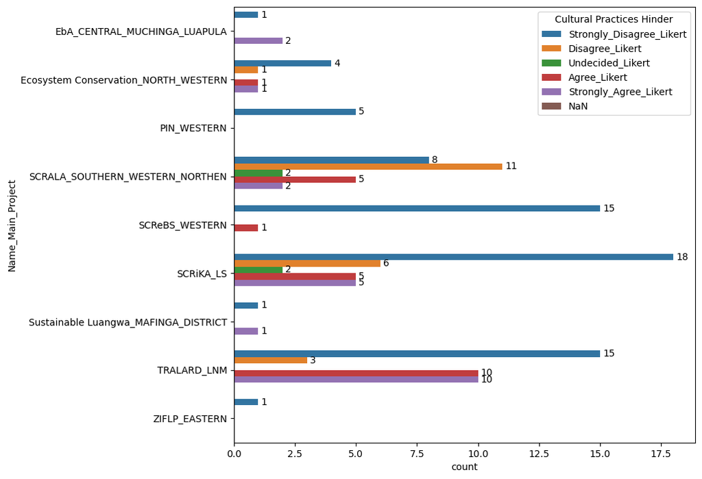

```python
plt.figure(figsize=(8.7, 8.27))
hue_order = ["Strongly_Disagree_Likert", "Disagree_Likert", "Undecided_Likert", "Agree_Likert", "Strongly_Agree_Likert", "NaN"]
ax = sns.barplot(data = CPH_grouped1, x="count", y="Name_Main_Project", hue="Cultural_Practices_Hinder", hue_order=hue_order, legend=True)
plt.legend(title="Cultural Practices Hinder")
for container in ax.containers:
    ax.bar_label(container, fmt="%.0f", label_type="edge", padding=3)
plt.show()
```

```python
agreement_levels = ["Agree_Likert", "Strongly_Agree_Likert"]
#filtered_df = df2[df[Cultural_Practices_Hinder].isin(agreement_levels).any(axis=1)]
CPH_R = df2[df2["Cultural_Practices_Hinder"].isin(agreement_levels)]
```

```python
CPH_R1 = CPH_R.drop(CPH_R.columns[[0,1,2,3,4,6,7,10,11,12,13,14,15,16,17,18,19,20,21,22,23,24,25,26,27,28,29,30,31,32,33,34]], axis = 1)
CPH_R1grouped = CPH_R1.groupby('Name_Main_Project')['Cultural_Practices_Hinder']
CPH_R1
```

|  | Name_Main_Project | Cultural_Practices_Hinder | Cultural_Practices_Hinder_Reason |
| --- | --- | --- | --- |
| 0 | TRALARD_LNM | Agree_Likert | It has never happed before in his life time |
| 1 | TRALARD_LNM | Strongly_Agree_Likert | There is need to harvest tree when they have fully grown the same applies to biodiversity |
| 3 | TRALARD_LNM | Strongly_Agree_Likert | There are rotations made on the land when cultivation to ensure fetility of soil |
| 6 | TRALARD_LNM | Agree_Likert | Therevis nothing |
| 7 | TRALARD_LNM | Strongly_Agree_Likert | You are allowed to cultivate an area for 3 years before shifting yo another area |
| 11 | TRALARD_LNM | Strongly_Agree_Likert | There rules from the chiefs who ensurex the harvesting period are followed as well as the periond vor burining the bush |
| 12 | TRALARD_LNM | Strongly_Agree_Likert | There is a norms of the period when the bush has to be be burt sothe the bush is not completely burnt |
| 17 | TRALARD_LNM | Strongly_Agree_Likert | There is nothing |
| 19 | TRALARD_LNM | Strongly_Agree_Likert | He has nevervhearfvof the or leqrntbabout it |
| 22 | TRALARD_LNM | Strongly_Agree_Likert | The cutting down of tree along the river is not allowed |
| 23 | EbA_CENTRAL_MUCHINGA_LUAPULA | Strongly_Agree_Likert | There acts of late burning that distroys the environment as they wouod want to catch catapilars |
| 24 | TRALARD_LNM | Agree_Likert | Because ablong time people had porr management of natiral bit atv thr moment there are practice to matain bidovesity |
| 25 | TRALARD_LNM | Strongly_Agree_Likert | If tyere ciktural practices the firturr genrationbwill not inow anything |
| 27 | TRALARD_LNM | Strongly_Agree_Likert | There customaryb practices sayd early burning but some peolr tend to burn late |
| 29 | EbA_CENTRAL_MUCHINGA_LUAPULA | Strongly_Agree_Likert | The unreguoayed allocation of oarcels of land in thebforests |
| 31 | TRALARD_LNM | Agree_Likert | Ba chipupila"" they have customary practices for protecting the natural resources |
| 32 | TRALARD_LNM | Agree_Likert | Thete are places such as grave yard which are ptotectwd form deforestation |
| 35 | SCRALA_SOUTHERN_WESTERN_NORTHEN | Agree_Likert | The land where the natural resources arec lovatedcare ownde bybthe traditional authority |
| 37 | TRALARD_LNM | Agree_Likert | Chitemene system system distroys the enviroment |
| 39 | SCRALA_SOUTHERN_WESTERN_NORTHEN | Agree_Likert | I have experience the cuktural prqctices interfering forst management |
| 41 | SCRALA_SOUTHERN_WESTERN_NORTHEN | Strongly_Agree_Likert | Our old parents taught us to rpotect the environmnetbso that is more like a customary practice |
| 46 | SCRALA_SOUTHERN_WESTERN_NORTHEN | Agree_Likert | The rules that arevmade are customary practices that shoukd be followed |
| 47 | TRALARD_LNM | Agree_Likert | There places that they do not allow cuttingbtrees as well as cuttingbfrutbbearingbtrees |
| 49 | TRALARD_LNM | Agree_Likert | If there is no protectionnof the enviribemnt the resources cqn be depletef |
| 53 | TRALARD_LNM | Agree_Likert | There is no cutingvof trees anyhow |
| 55 | TRALARD_LNM | Agree_Likert | Tehy teach us to protect the environment through preventing chitemene system |
| 56 | Ecosystem Conservation_NORTH_WESTERN | Strongly_Agree_Likert | We always teach peop,e or commu ity on how to protect the environemnt |
| 64 | Ecosystem Conservation_NORTH_WESTERN | Agree_Likert | The normally give rules on how to protect the environent |
| 65 | Sustainable Luangwa_MAFINGA_DISTRICT | Strongly_Agree_Likert | The tradituonal methods of harveting such as poaching, burning and cutting doen of trrees |
| 68 | SCRALA_SOUTHERN_WESTERN_NORTHEN | Agree_Likert | There are peopel who cut the tree and the animals lavk where to sleep |
| 71 | SCRiKA_LS | Strongly_Agree_Likert | There are practices such called ""malende"" that protect certain areas that prohibit trees from beeing cut down |
| 74 | SCRiKA_LS | Agree_Likert | There are hynas that eat our livesticks but when we kill them we are in onflict with ZAWA people |
| 76 | SCRiKA_LS | Strongly_Agree_Likert | The ownership of land by chief in the river gives them power to distry the area by giveing it out for cultivation activities |
| 79 | SCRALA_SOUTHERN_WESTERN_NORTHEN | Strongly_Agree_Likert | There cultural practices of that can prevent rains from falling if the ""malende"" has been disturbed |
| 80 | SCRALA_SOUTHERN_WESTERN_NORTHEN | Agree_Likert | There are bad fishing methods and as well people settling in the game parks |
| 93 | SCRiKA_LS | Agree_Likert | NaN |
| 95 | SCRiKA_LS | Agree_Likert | There is lack of supoort to the WDCS and CRB to the local commu ity to protect the environment. The lisence is given to people to cut trees but the community do not benfit but the only tradition autho… |
| 100 | SCRiKA_LS | Strongly_Agree_Likert | Some people are still want to lead a life of hunting and the use of mosquito for catching fish |
| 101 | SCRiKA_LS | Agree_Likert | NaN |
| 103 | SCRiKA_LS | Agree_Likert | The traditional leaders prohit people of making decksion and some sell the land to peole that lead to distruction of the environmeng ecen if people do not agree with ghe headman. They headman say it i… |
| 108 | SCRiKA_LS | Strongly_Agree_Likert | Some culturel activitie such as getiingbroits from trees for medicine can distroy the tres |
| 114 | SCRiKA_LS | Strongly_Agree_Likert | Our culture is that for soneone to live well needs to cultivate a huge land thus distroying the trees |
| 129 | SCReBS_WESTERN | Agree_Likert | The chief have been asking peole to stop living along the river banks and using mosquito net to fish but the community are not adhearing |

```python
lemmatizer=WordNetLemmatizer()
stop_words = set(stopwords.words('english'))
for index, row in CPH_R1.iterrows():
    CPH_R1_filter_sentence = []
    CPH_R1_sentence = row["Cultural_Practices_Hinder_Reason"]
    if pd.isnull(CPH_R1_sentence):
       continue
    CPH_R1_sentence_cleaned = re.sub(r'[^\w\s]','',CPH_R1_sentence)
    CPH_R1_words = nltk.word_tokenize(CPH_R1_sentence_cleaned)
    CPH_R1_words = [lemmatizer.lemmatize(w) for w in CPH_R1_words if w.lower() not in stop_words]
    CPH_R1_filter_sentence.extend(CPH_R1_words)
    print(CPH_R1_filter_sentence)
```

```
['never', 'happed', 'life', 'time']
['need', 'harvest', 'tree', 'fully', 'grown', 'applies', 'biodiversity']
['rotation', 'made', 'land', 'cultivation', 'ensure', 'fetility', 'soil']
['Therevis', 'nothing']
['allowed', 'cultivate', 'area', '3', 'year', 'shifting', 'yo', 'another', 'area']
['rule', 'chief', 'ensurex', 'harvesting', 'period', 'followed', 'well', 'periond', 'vor', 'burining', 'bush']
['norm', 'period', 'bush', 'burt', 'sothe', 'bush', 'completely', 'burnt']
['nothing']
['nevervhearfvof', 'leqrntbabout']
['cutting', 'tree', 'along', 'river', 'allowed']
['act', 'late', 'burning', 'distroys', 'environment', 'wouod', 'want', 'catch', 'catapilars']
['ablong', 'time', 'people', 'porr', 'management', 'natiral', 'bit', 'atv', 'thr', 'moment', 'practice', 'matain', 'bidovesity']
['tyere', 'ciktural', 'practice', 'firturr', 'genrationbwill', 'inow', 'anything']
['customaryb', 'practice', 'sayd', 'early', 'burning', 'peolr', 'tend', 'burn', 'late']
['unreguoayed', 'allocation', 'oarcels', 'land', 'thebforests']
['Ba', 'chipupila', 'customary', 'practice', 'protecting', 'natural', 'resource']
['Thete', 'place', 'grave', 'yard', 'ptotectwd', 'form', 'deforestation']
['land', 'natural', 'resource', 'arec', 'lovatedcare', 'ownde', 'bybthe', 'traditional', 'authority']
['Chitemene', 'system', 'system', 'distroys', 'enviroment']
['experience', 'cuktural', 'prqctices', 'interfering', 'forst', 'management']
['old', 'parent', 'taught', 'u', 'rpotect', 'environmnetbso', 'like', 'customary', 'practice']
['rule', 'arevmade', 'customary', 'practice', 'shoukd', 'followed']
['place', 'allow', 'cuttingbtrees', 'well', 'cuttingbfrutbbearingbtrees']
['protectionnof', 'enviribemnt', 'resource', 'cqn', 'depletef']
['cutingvof', 'tree', 'anyhow']
['Tehy', 'teach', 'u', 'protect', 'environment', 'preventing', 'chitemene', 'system']
['always', 'teach', 'peope', 'commu', 'ity', 'protect', 'environemnt']
['normally', 'give', 'rule', 'protect', 'environent']
['tradituonal', 'method', 'harveting', 'poaching', 'burning', 'cutting', 'doen', 'trrees']
['peopel', 'cut', 'tree', 'animal', 'lavk', 'sleep']
['practice', 'called', 'malende', 'protect', 'certain', 'area', 'prohibit', 'tree', 'beeing', 'cut']
['hynas', 'eat', 'livesticks', 'kill', 'onflict', 'ZAWA', 'people']
['ownership', 'land', 'chief', 'river', 'give', 'power', 'distry', 'area', 'giveing', 'cultivation', 'activity']
['cultural', 'practice', 'prevent', 'rain', 'falling', 'malende', 'disturbed']
['bad', 'fishing', 'method', 'well', 'people', 'settling', 'game', 'park']
['lack', 'supoort', 'WDCS', 'CRB', 'local', 'commu', 'ity', 'protect', 'environment', 'lisence', 'given', 'people', 'cut', 'tree', 'community', 'benfit', 'tradition', 'authority', 'benefit']
['people', 'still', 'want', 'lead', 'life', 'hunting', 'use', 'mosquito', 'catching', 'fish']
['traditional', 'leader', 'prohit', 'people', 'making', 'decksion', 'sell', 'land', 'peole', 'lead', 'distruction', 'environmeng', 'ecen', 'people', 'agree', 'ghe', 'headman', 'headman', 'say', 'land', 'sell', 'want']
['culturel', 'activitie', 'getiingbroits', 'tree', 'medicine', 'distroy', 'tres']
['culture', 'soneone', 'live', 'well', 'need', 'cultivate', 'huge', 'land', 'thus', 'distroying', 'tree']
['chief', 'asking', 'peole', 'stop', 'living', 'along', 'river', 'bank', 'using', 'mosquito', 'net', 'fish', 'community', 'adhearing']
```

```python
agreement_levels = ["Disagree_Likert", "Strongly_Disagree_Likert"]
#filtered_df = df2[df[Cultural_Practices_Hinder].isin(agreement_levels).any(axis=1)]
CPH_R2 = df2[df2["Cultural_Practices_Hinder"].isin(agreement_levels)]
```

```python
CPH_R3 = CPH_R2.drop(CPH_R2.columns[[0,1,2,3,4,6,7,10,11,12,13,14,15,16,17,18,19,20,21,22,23,24,25,26,27,28,29,30,31,32,33,34]], axis = 1)
CPH_R3grouped = CPH_R3.groupby('Name_Main_Project')['Cultural_Practices_Hinder']
CPH_R3
```

|  | Name_Main_Project | Cultural_Practices_Hinder | Cultural_Practices_Hinder_Reason |
| --- | --- | --- | --- |
| 2 | TRALARD_LNM | Strongly_Disagree_Likert | There are no customary practices that hinder sustainable management |
| 4 | TRALARD_LNM | Strongly_Disagree_Likert | There is nothing |
| 5 | TRALARD_LNM | Strongly_Disagree_Likert | There is nothing |
| 8 | TRALARD_LNM | Strongly_Disagree_Likert | There is nothing |
| 9 | TRALARD_LNM | Strongly_Disagree_Likert | There is nothing |
| ... | ... | ... | ... |
| 144 | PIN_WESTERN | Strongly_Disagree_Likert | There is nothjng |
| 146 | PIN_WESTERN | Strongly_Disagree_Likert | There is nothing |
| 147 | PIN_WESTERN | Strongly_Disagree_Likert | There is nthing |
| 148 | PIN_WESTERN | Strongly_Disagree_Likert | There is nothing |
| 149 | SCReBS_WESTERN | Strongly_Disagree_Likert | There is nothing |

90 rows Ã— 3 columns

```python
lemmatizer=WordNetLemmatizer()
stop_words = set(stopwords.words('english'))
for index, row in CPH_R3.iterrows():
    CPH_R3_filter_sentence = []
    CPH_R3_sentence = row["Cultural_Practices_Hinder_Reason"]
    if pd.isnull(CPH_R3_sentence):
       continue
    CPH_R3_sentence_cleaned = re.sub(r'[^\w\s]','',CPH_R3_sentence)
    CPH_R3_words = nltk.word_tokenize(CPH_R3_sentence_cleaned)
    CPH_R3_words = [lemmatizer.lemmatize(w) for w in CPH_R3_words if w.lower() not in stop_words]
    CPH_R3_filter_sentence.extend(CPH_R3_words)
    print(CPH_R3_filter_sentence)
```

```
['customary', 'practice', 'hinder', 'sustainable', 'management']
['nothing']
['nothing']
['nothing']
['nothing']
['cultural', 'history', 'within', 'community', 'e', 'cept', 'governmnet']
['cultural', 'norm']
['nothing']
['nothing']
['Threr', 'nothing']
['cusyomsry', 'practice', 'protect', 'thr', 'environment', 'like', 'Zawa', 'protect', 'thr', 'biofiversiyy']
['chitemene', 'system', 'customary', 'practice', 'thatvdestroys', 'envirinment']
['cultural', 'practice', 'burn', 'thr', 'bushbatv', 'certain', 'periid', 'harvrsting']
['cultural', 'practice']
['nothing']
['nothing']
['nothing']
['nothing']
['nothing']
['Tgere', 'nirhing']
['nothing']
['Tehre', 'nothing']
['nothinhg']
['traditional', 'practicrs', 'butbit', 'governemnt', 'thatvguides', 'u', 'whatvwe', 'shoukd']
['nothing']
['nothing']
['nothing', 'looked', 'game', 'parknofficers']
['Tehre', 'nothing']
['ia', 'nothing']
['noth8ng']
['nothing']
['othing']
['nothing']
['tradigional', 'way', 'mangement', 'stoped', 'govermnent', 'taken', 'management', 'forest', 'biodiversity']
['nothing']
['long', 'time', 'malende', 'used', 'protect', 'tree', 'moment', 'taking', 'place']
['nothing']
['nothing']
['nothing']
['heqrd', 'qnything', 'like']
```

[output cut: 32 more lines]

```
['nothing']
['Thwre', 'nothing']
['nothing']
['nothing']
['nothing']
['8', 'nothing']
['nothing']
['nothing']
['nothing']
['Therevis', 'nothing']
['nothjng']
['nothing']
['nthing']
['nothing']
['nothing']
```

11.2 Main project and Cultural Practices Changed

```python
CPC_grouped = df2.groupby('Name_Main_Project')['Cultural_Practices_Changed'].value_counts(dropna=False)
```

```python
CPC_grouped
```

```
Name_Main_Project                     Cultural_Practices_Changed
EbA_CENTRAL_MUCHINGA_LUAPULA          Strongly_Agree_Likert          1
                                      Strongly_Disagree_Likert       1
                                      Undecided_Likert               1
                                      NaN                            1
Ecosystem Conservation_NORTH_WESTERN  NaN                            4
                                      Strongly_Agree_Likert          3
                                      Strongly_Disagree_Likert       2
PIN_WESTERN                           Strongly_Disagree_Likert       4
                                      Strongly_Agree_Likert          1
SCRALA_SOUTHERN_WESTERN_NORTHEN       Agree_Likert                  10
                                      Disagree_Likert                7
                                      Strongly_Disagree_Likert       4
                                      Undecided_Likert               4
                                      Strongly_Agree_Likert          3
                                      NaN                            1
SCReBS_WESTERN                        Strongly_Disagree_Likert       6
                                      Agree_Likert                   5
                                      Strongly_Agree_Likert          5
SCRiKA_LS                             Agree_Likert                  11
                                      Strongly_Agree_Likert         10
                                      NaN                            9
                                      Disagree_Likert                5
                                      Strongly_Disagree_Likert       5
                                      Undecided_Likert               1
Sustainable Luangwa_MAFINGA_DISTRICT  Strongly_Agree_Likert          1
                                      NaN                            1
TRALARD_LNM                           Strongly_Disagree_Likert      18
                                      Disagree_Likert               10
                                      Strongly_Agree_Likert          5
                                      Agree_Likert                   3
                                      Undecided_Likert               2
                                      NaN                            2
ZIFLP_EASTERN                         Undecided_Likert               1
Name: count, dtype: int64
```

```python
CPC_grouped1 = pd.DataFrame(CPC_grouped)
```

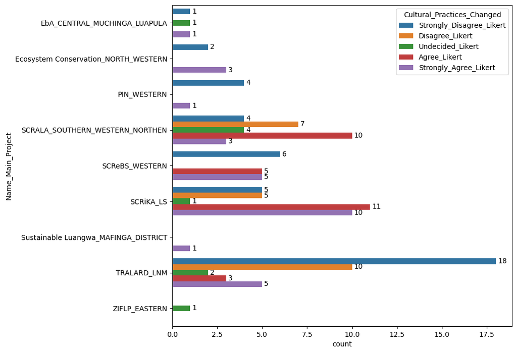

```python
plt.figure(figsize=(8.7, 8.27))
hue_order = ["Strongly_Disagree_Likert", "Disagree_Likert", "Undecided_Likert", "Agree_Likert", "Strongly_Agree_Likert"]
ax = sns.barplot(data = CPC_grouped1, x="count", y="Name_Main_Project", hue="Cultural_Practices_Changed", hue_order=hue_order, legend=True)
plt.legend(title="Cultural_Practices_Changed")
for container in ax.containers:
    ax.bar_label(container, fmt="%.0f", label_type="edge", padding=3)
plt.show()
```

11.3 Main project and Cultural Aspects Considered

```python
CAC_grouped = df2.groupby('Name_Main_Project')['Cultural_Aspects_Considered'].value_counts(dropna=False)
```

```python
CAC_grouped1 = pd.DataFrame(CAC_grouped)
```

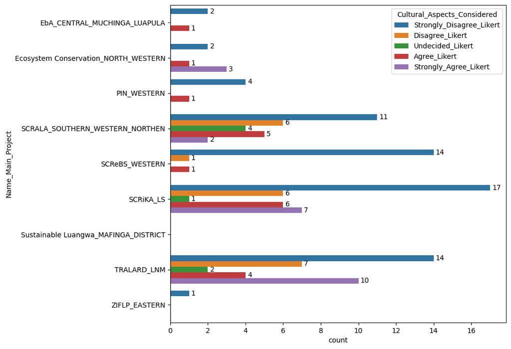

```python
plt.figure(figsize=(8.7, 8.27))
hue_order = ["Strongly_Disagree_Likert", "Disagree_Likert", "Undecided_Likert", "Agree_Likert", "Strongly_Agree_Likert"]
ax = sns.barplot(data = CAC_grouped1, x="count", y="Name_Main_Project", hue="Cultural_Aspects_Considered", hue_order=hue_order, legend=True)
plt.legend(title="Cultural_Aspects_Considered")
for container in ax.containers:
    ax.bar_label(container, fmt="%.0f", label_type="edge", padding=3)
plt.show()
```

```python
agreement_levels = ["Agree_Likert", "Strongly_Agree_Likert"]
CAC_R = df2[df2["Cultural_Aspects_Considered"].isin(agreement_levels)]
CAC_R1 = CAC_R.drop(CPH_R.columns[[0,1,2,3,4,6,7,8,9,10,13,14,15,16,17,18,19,20,21,22,23,24,25,26,27,28,29,30,31,32,33,34]], axis = 1)
CAC_R1grouped = CAC_R1.groupby('Name_Main_Project')['Cultural_Aspects_Considered']
CAC_R1
```

|  | Name_Main_Project | Cultural_Aspects_Considered | Cultural_Aspects_Considered_Reasons |
| --- | --- | --- | --- |
| 1 | TRALARD_LNM | Strongly_Agree_Likert | There is need to have power in what he formulating so that there is ownership |
| 3 | TRALARD_LNM | Strongly_Agree_Likert | At the time of getting the land for the project it commes with regulations |
| 7 | TRALARD_LNM | Strongly_Agree_Likert | There rules thatvatvthe river banks they do not need to cut downntrees |
| 11 | TRALARD_LNM | Strongly_Agree_Likert | There are sometimes we have to givd the chiefs frpm the the havest that the collect or produce that has to be accounted for |
| 17 | TRALARD_LNM | Strongly_Agree_Likert | There is nothing because that thongs ended a long time ago the chiefs would talk to thr spirits to prptect yhe land |
| 21 | TRALARD_LNM | Strongly_Agree_Likert | Thsy arebnot included |
| 22 | TRALARD_LNM | Strongly_Agree_Likert | If there arevno customarybpractices thr natutal resourcrs can getv distroyed |
| 23 | EbA_CENTRAL_MUCHINGA_LUAPULA | Agree_Likert | No answer |
| 24 | TRALARD_LNM | Agree_Likert | No answer |
| 25 | TRALARD_LNM | Agree_Likert | If if is not done the product or project will not work well |
| 27 | TRALARD_LNM | Strongly_Agree_Likert | We foolows the customary practiced but peolr burn late which is unorder |
| 28 | TRALARD_LNM | Strongly_Agree_Likert | We do it so other our livelihood canninprove |
| 31 | TRALARD_LNM | Agree_Likert | We just folow the historical practices of our forefathers |
| 32 | TRALARD_LNM | Strongly_Agree_Likert | There cultural practices such as spririal rites done by traditiknal authority |
| 33 | SCRALA_SOUTHERN_WESTERN_NORTHEN | Strongly_Agree_Likert | The accessing of land from the tradiyional authorithy who also give imstrutioms of where to put livelihood noy close to the water sources |
| 35 | SCRALA_SOUTHERN_WESTERN_NORTHEN | Agree_Likert | A project cannot ooerate without consuktingbthe traditional authority |
| 39 | SCRALA_SOUTHERN_WESTERN_NORTHEN | Agree_Likert | No answer |
| 44 | SCRALA_SOUTHERN_WESTERN_NORTHEN | Agree_Likert | Sonetime webdiscuss locally how the animals are going to be lokked after |
| 46 | SCRALA_SOUTHERN_WESTERN_NORTHEN | Agree_Likert | We akways folow the laws that are taught ti us |
| 49 | TRALARD_LNM | Agree_Likert | We cqn distry the environment if tgere are no customary pracyoces |
| 56 | Ecosystem Conservation_NORTH_WESTERN | Strongly_Agree_Likert | The we cqnnoy be changed because we wojld like to havr the envirnment proted for our to see them in vuture |
| 57 | Ecosystem Conservation_NORTH_WESTERN | Strongly_Agree_Likert | Previusly peopel used to cut trees anyhow but now there is change |
| 59 | Ecosystem Conservation_NORTH_WESTERN | Agree_Likert | The cultural aspectes are consodered because the are within the cfmg |
| 66 | Ecosystem Conservation_NORTH_WESTERN | Strongly_Agree_Likert | Even the bible says do not forget your roots |
| 68 | SCRALA_SOUTHERN_WESTERN_NORTHEN | Agree_Likert | We are always follow what we are told |
| 70 | SCRiKA_LS | Strongly_Agree_Likert | We have to consider it because if it is not the projects would not work well for instance in livingstone the community distroyed the the cultural activities of northwestern because they came from a di… |
| 72 | SCRiKA_LS | Strongly_Agree_Likert | The borehole can not be sank near the grave yard and when there is funneral in the community you cannot hold a meeting in the village |
| 75 | SCRiKA_LS | Agree_Likert | NaN |
| 76 | SCRiKA_LS | Agree_Likert | The groups have thier own missio like our group we give money to the orphans from the profit we make |
| 79 | SCRALA_SOUTHERN_WESTERN_NORTHEN | Strongly_Agree_Likert | We do not do it |
| 85 | SCRiKA_LS | Strongly_Agree_Likert | We do not |
| 92 | SCRiKA_LS | Agree_Likert | No answer |
| 93 | SCRiKA_LS | Agree_Likert | NaN |
| 94 | SCRiKA_LS | Agree_Likert | NaN |
| 95 | SCRiKA_LS | Agree_Likert | They are considered because the thatched roof, usjng poles for the cattle craw are some of yje cultural aspects that are diffficukt to change unless peopel have enough money |
| 100 | SCRiKA_LS | Strongly_Agree_Likert | The project ie bettering our lives |
| 109 | SCRiKA_LS | Strongly_Agree_Likert | NaN |
| 110 | SCRiKA_LS | Strongly_Agree_Likert | When we have been taught |
| 115 | SCRiKA_LS | Strongly_Agree_Likert | The traditionql leaders hqve to acceptbthat a certain project has to be done on a specific place |
| 141 | SCReBS_WESTERN | Agree_Likert | We invpcukdede Ä£gevv induna |
| 146 | PIN_WESTERN | Agree_Likert | Only the indunas that send tye representative to learn and they accept the project in the community |

```python
lemmatizer=WordNetLemmatizer()
stop_words = set(stopwords.words('english'))
for index, row in CAC_R1.iterrows():
    CAC_R1_filter_sentence = []
    CAC_R1_sentence = row["Cultural_Aspects_Considered_Reasons"]
    if pd.isnull(CAC_R1_sentence):
       continue
    CAC_R1_sentence_cleaned = re.sub(r'[^\w\s]','',CAC_R1_sentence)
    CAC_R1_words = nltk.word_tokenize(CAC_R1_sentence_cleaned)
    CAC_R1_words = [lemmatizer.lemmatize(w) for w in CAC_R1_words if w.lower() not in stop_words]
    CAC_R1_filter_sentence.extend(CAC_R1_words)
    print(CAC_R1_filter_sentence)
```

```
['need', 'power', 'formulating', 'ownership']
['time', 'getting', 'land', 'project', 'commes', 'regulation']
['rule', 'thatvatvthe', 'river', 'bank', 'need', 'cut', 'downntrees']
['sometimes', 'givd', 'chief', 'frpm', 'havest', 'collect', 'produce', 'accounted']
['nothing', 'thong', 'ended', 'long', 'time', 'ago', 'chief', 'would', 'talk', 'thr', 'spirit', 'prptect', 'yhe', 'land']
['Thsy', 'arebnot', 'included']
['arevno', 'customarybpractices', 'thr', 'natutal', 'resourcrs', 'getv', 'distroyed']
['answer']
['answer']
['done', 'product', 'project', 'work', 'well']
['foolows', 'customary', 'practiced', 'peolr', 'burn', 'late', 'unorder']
['livelihood', 'canninprove']
['folow', 'historical', 'practice', 'forefather']
['cultural', 'practice', 'spririal', 'rite', 'done', 'traditiknal', 'authority']
['accessing', 'land', 'tradiyional', 'authorithy', 'also', 'give', 'imstrutioms', 'put', 'livelihood', 'noy', 'close', 'water', 'source']
['project', 'ooerate', 'without', 'consuktingbthe', 'traditional', 'authority']
['answer']
['Sonetime', 'webdiscuss', 'locally', 'animal', 'going', 'lokked']
['akways', 'folow', 'law', 'taught', 'ti', 'u']
['cqn', 'distry', 'environment', 'tgere', 'customary', 'pracyoces']
['cqnnoy', 'changed', 'wojld', 'like', 'havr', 'envirnment', 'proted', 'see', 'vuture']
['Previusly', 'peopel', 'used', 'cut', 'tree', 'anyhow', 'change']
['cultural', 'aspectes', 'consodered', 'within', 'cfmg']
['Even', 'bible', 'say', 'forget', 'root']
['always', 'follow', 'told']
['consider', 'project', 'would', 'work', 'well', 'instance', 'livingstone', 'community', 'distroyed', 'cultural', 'activity', 'northwestern', 'came', 'diffrent', 'region']
['borehole', 'sank', 'near', 'grave', 'yard', 'funneral', 'community', 'hold', 'meeting', 'village']
['group', 'thier', 'missio', 'like', 'group', 'give', 'money', 'orphan', 'profit', 'make']
[]
[]
['answer']
['considered', 'thatched', 'roof', 'usjng', 'pole', 'cattle', 'craw', 'yje', 'cultural', 'aspect', 'diffficukt', 'change', 'unless', 'peopel', 'enough', 'money']
['project', 'ie', 'bettering', 'life']
['taught']
['traditionql', 'leader', 'hqve', 'acceptbthat', 'certain', 'project', 'done', 'specific', 'place']
['invpcukdede', 'Ä£gevv', 'induna']
['indunas', 'send', 'tye', 'representative', 'learn', 'accept', 'project', 'community']
```

```python
agreement_levels = ["Disagree_Likert", "Strongly_Disagree_Likert"]
CAC_R2 = df2[df2["Cultural_Aspects_Considered"].isin(agreement_levels)]
CAC_R3 = CAC_R2.drop(CPH_R2.columns[[0,1,2,3,4,6,7,8,9,10,13,14,15,16,17,18,19,20,21,22,23,24,25,26,27,28,29,30,31,32,33,34]], axis = 1)
CAC_R3grouped = CAC_R3.groupby('Name_Main_Project')['Cultural_Aspects_Considered']
CAC_R3
```

|  | Name_Main_Project | Cultural_Aspects_Considered | Cultural_Aspects_Considered_Reasons |
| --- | --- | --- | --- |
| 0 | TRALARD_LNM | Strongly_Disagree_Likert | There are no cultural history in the area |
| 2 | TRALARD_LNM | Strongly_Disagree_Likert | There are nop cultural aspects |
| 4 | TRALARD_LNM | Strongly_Disagree_Likert | We only follow what the chiefs and the governmnet say |
| 5 | TRALARD_LNM | Strongly_Disagree_Likert | There is nothing |
| 6 | TRALARD_LNM | Strongly_Disagree_Likert | There is nothing |
| ... | ... | ... | ... |
| 143 | SCReBS_WESTERN | Strongly_Disagree_Likert | They are not included |
| 144 | PIN_WESTERN | Strongly_Disagree_Likert | We do not include |
| 147 | PIN_WESTERN | Strongly_Disagree_Likert | There is nothing |
| 148 | PIN_WESTERN | Strongly_Disagree_Likert | There is nothing |
| 149 | SCReBS_WESTERN | Strongly_Disagree_Likert | We do not do it |

86 rows Ã— 3 columns

```python
lemmatizer=WordNetLemmatizer()
stop_words = set(stopwords.words('english'))
for index, row in CAC_R3.iterrows():
    CAC_R3_filter_sentence = []
    CAC_R3_sentence = row["Cultural_Aspects_Considered_Reasons"]
    if pd.isnull(CAC_R3_sentence):
       continue
    CAC_R3_sentence_cleaned = re.sub(r'[^\w\s]','',CAC_R3_sentence)
    CAC_R3_words = nltk.word_tokenize(CAC_R3_sentence_cleaned)
    CAC_R3_words = [lemmatizer.lemmatize(w) for w in CAC_R3_words if w.lower() not in stop_words]
    CAC_R3_filter_sentence.extend(CAC_R3_words)
    print(CAC_R3_filter_sentence)
```

```
['cultural', 'history', 'area']
['nop', 'cultural', 'aspect']
['follow', 'chief', 'governmnet', 'say']
['nothing']
['nothing']
['nothing']
['mothing']
['plan', 'given', 'tralard', 'condiderstion', 'cultural', 'history', 'wh3n', 'formulating', 'project']
['nothi', 'g']
['moment', 'follow', 'law', 'government', 'cultural', 'norm']
['nothing']
['ask', 'headman', 'give', 'u', 'place', 'keep', 'goat', 'place', 'acceptable', 'taraditional', 'law']
['mothing', 'momentvof', 'havong', 'traditional', 'leader', 'spritual', 'tje', 'project']
['include', 'culturwl', 'practice']
['project', 'move', 'well', 'headman', 'thr', 'project', 'migjy', 'havr', 'problem']
['Thetev', 'raevnot', 'available']
['consider']
['u', 'nothing']
['nithing']
[]
['nothing']
['noy']
['unneccesaary']
['anytging']
[]
['nothing']
['donot', 'include']
[]
['nothing']
['include', 'aspect']
['nothing']
['Tgere', 'nothing', 'luded']
['Nothing', 'onsiderd']
['nothing']
[]
['Nothing', 'cons8derd']
['nothing']
['inclued']
['clude']
['Ther', 'nothing', 'inclued']
```

[output cut: 22 more lines]

```
[]
[]
['Nothing']
[]
['nothing']
['follow', 'teachjngs']
['cultural', 'included']
['cultural', 'aspect', 'included']
[]
[]
['included']
['include']
['nothing']
['nothing']
[]
```

11.4 Main project and Measure of Indicators

```python
MI_grouped = df2.groupby('Name_Main_Project')['Measure_Indicators'].value_counts(dropna=False)
```

```python
MI_grouped1 = pd.DataFrame(MI_grouped)
```

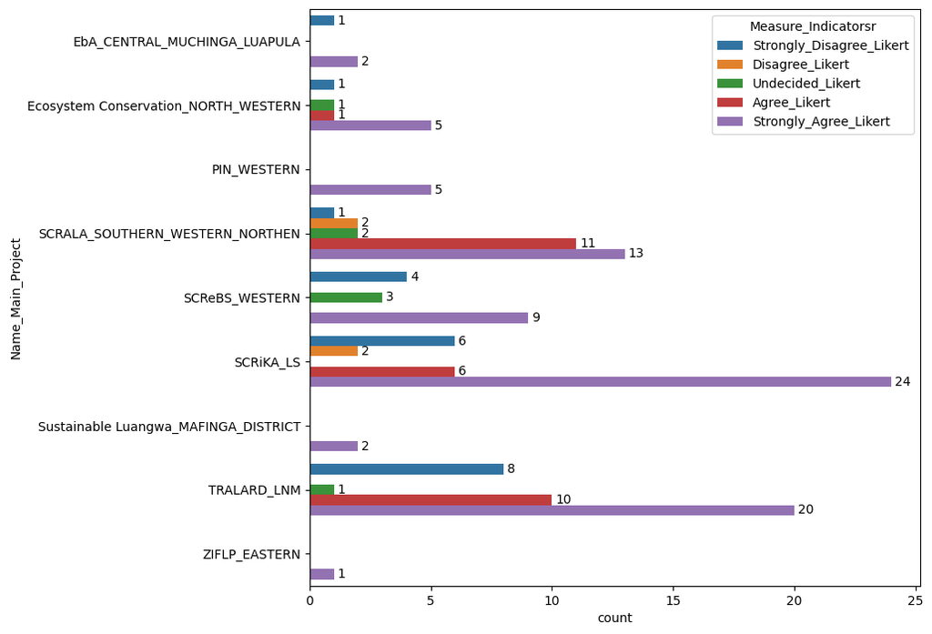

```python
plt.figure(figsize=(8.7, 8.27))
hue_order = ["Strongly_Disagree_Likert", "Disagree_Likert", "Undecided_Likert", "Agree_Likert", "Strongly_Agree_Likert"]
ax = sns.barplot(data = MI_grouped1, x="count", y="Name_Main_Project", hue="Measure_Indicators", hue_order=hue_order, legend=True)
plt.legend(title="Measure_Indicatorsr")
for container in ax.containers:
    ax.bar_label(container, fmt="%.0f", label_type="edge", padding=3)
plt.show()
```

11.5 Main project and Livelihood Dependent

```python
LD_grouped = df2.groupby('Name_Main_Project')['Livilihood_Depenedent'].value_counts(dropna=False)
```

```python
LD_grouped1 = pd.DataFrame(LD_grouped)
```

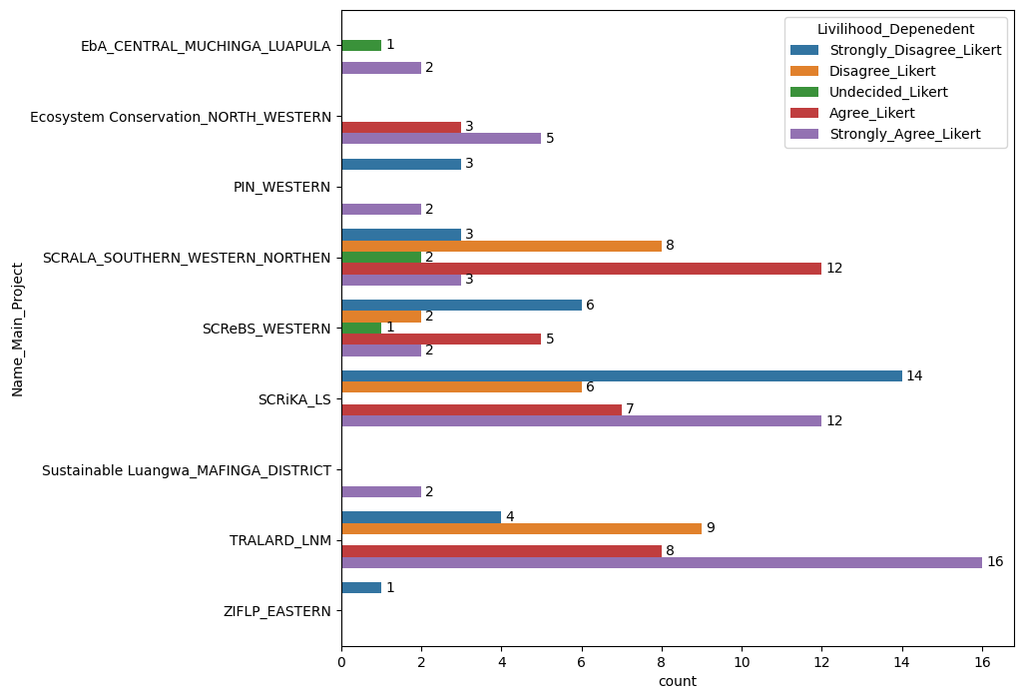

```python
plt.figure(figsize=(8.7, 8.27))
hue_order = ["Strongly_Disagree_Likert", "Disagree_Likert", "Undecided_Likert", "Agree_Likert", "Strongly_Agree_Likert"]
ax = sns.barplot(data = LD_grouped1, x="count", y="Name_Main_Project", hue="Livilihood_Depenedent", hue_order=hue_order, legend=True)
plt.legend(title="Livilihood_Depenedent")
for container in ax.containers:
    ax.bar_label(container, fmt="%.0f", label_type="edge", padding=3)
plt.show()
```

11.6 Main project and Livelihood Changed

```python
CL_grouped = df2.groupby('Name_Main_Project')['Change_Livelihood'].value_counts(dropna=False)
```

```python
CL_grouped1 = pd.DataFrame(CL_grouped)
```

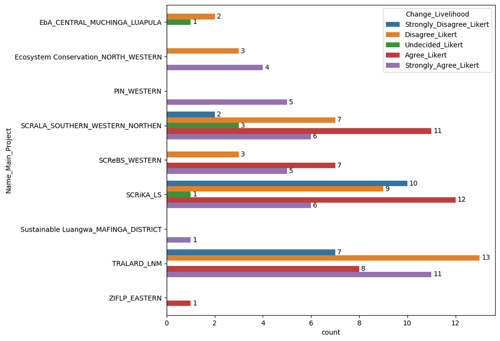

```python
plt.figure(figsize=(8.7, 8.27))
hue_order = ["Strongly_Disagree_Likert", "Disagree_Likert", "Undecided_Likert", "Agree_Likert", "Strongly_Agree_Likert"]
ax = sns.barplot(data = CL_grouped1, x="count", y="Name_Main_Project", hue="Change_Livelihood", hue_order=hue_order, legend=True)
plt.legend(title="Change_Livelihood")
for container in ax.containers:
    ax.bar_label(container, fmt="%.0f", label_type="edge", padding=3)
plt.show()
```

11.7 Main project and Livelihood Changing Easy

```python
CLE_grouped = df2.groupby('Name_Main_Project')['Change_Livelihood_Easy'].value_counts(dropna=False)
```

```python
CLE_grouped1 = pd.DataFrame(CLE_grouped)
```

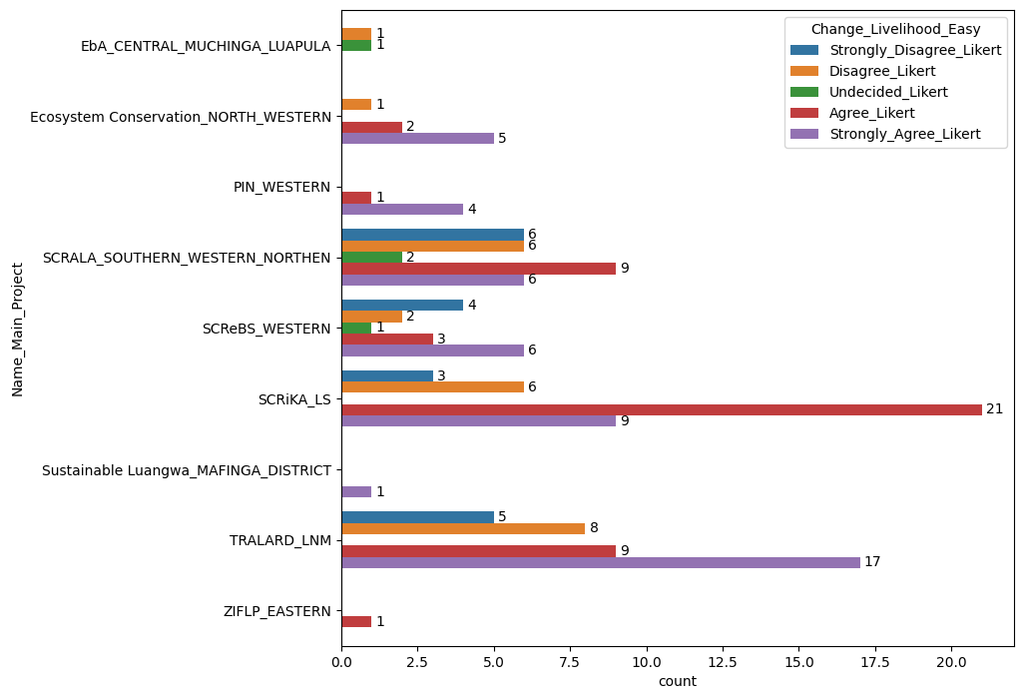

```python
plt.figure(figsize=(8.7, 8.27))
hue_order = ["Strongly_Disagree_Likert", "Disagree_Likert", "Undecided_Likert", "Agree_Likert", "Strongly_Agree_Likert"]
ax = sns.barplot(data = CLE_grouped1, x="count", y="Name_Main_Project", hue="Change_Livelihood_Easy", hue_order=hue_order, legend=True)
plt.legend(title="Change_Livelihood_Easy")
for container in ax.containers:
    ax.bar_label(container, fmt="%.0f", label_type="edge", padding=3)
plt.show()
```

```python
agreement_levels = ["Agree_Likert", "Strongly_Agree_Likert"]
CLE_R = df2[df2["Change_Livelihood_Easy"].isin(agreement_levels)]
CLE_R1 = CLE_R.drop(CLE_R.columns[[0,1,2,3,4,6,7,8,9,10,11,12,13,14,15,16,17,18,19,22,23,24,25,26,27,28,29,30,31,32,33,34]], axis = 1)
CLE_R1grouped = CLE_R1.groupby('Name_Main_Project')['Change_Livelihood_Easy']
CLE_R1
```

|  | Name_Main_Project | Change_Livelihood_Easy | Change_Livelihood_Easy_Reasons |
| --- | --- | --- | --- |
| 0 | TRALARD_LNM | Strongly_Agree_Likert | If the SES are taken care of they can increase in number and bring income to him |
| 1 | TRALARD_LNM | Strongly_Agree_Likert | The SeS can be depleted thus there need to chang to agrivulture like goat rearing |
| 2 | TRALARD_LNM | Agree_Likert | Change is easier because he is the one who has deciededs to change |
| 4 | TRALARD_LNM | Strongly_Agree_Likert | There has been thongs like climate change affecting us tjus the thought to chnage |
| 5 | TRALARD_LNM | Strongly_Agree_Likert | If there is new improvement like cooking stove we can change the way of livelihoode |
| ... | ... | ... | ... |
| 144 | PIN_WESTERN | Agree_Likert | It is easier as long as there is committment |
| 146 | PIN_WESTERN | Strongly_Agree_Likert | The perwon can make a deciosn through lookig back what heor she done so as to make corrective measures |
| 147 | PIN_WESTERN | Strongly_Agree_Likert | As long as you aare commiteted |
| 148 | PIN_WESTERN | Strongly_Agree_Likert | It is diffi jlt but as long as uou follow whag hou have been gaught uou can change |
| 149 | SCReBS_WESTERN | Strongly_Agree_Likert | As long sa i have the capacity to do so |

95 rows Ã— 3 columns

```python
lemmatizer=WordNetLemmatizer()
stop_words = set(stopwords.words('english'))
for index, row in CLE_R1.iterrows():
    CLE_R1_filter_sentence = []
    CLE_R1_sentence = row["Change_Livelihood_Easy_Reasons"]
    if pd.isnull(CLE_R1_sentence):
       continue
    CLE_R1_sentence_cleaned = re.sub(r'[^\w\s]','',CLE_R1_sentence)
    CLE_R1_words = nltk.word_tokenize(CLE_R1_sentence_cleaned)
    CLE_R1_words = [lemmatizer.lemmatize(w) for w in CLE_R1_words if w.lower() not in stop_words]
    CLE_R1_filter_sentence.extend(CLE_R1_words)
    print(CLE_R1_filter_sentence)
```

```
['SES', 'taken', 'care', 'increase', 'number', 'bring', 'income']
['SeS', 'depleted', 'thus', 'need', 'chang', 'agrivulture', 'like', 'goat', 'rearing']
['Change', 'easier', 'one', 'deciededs', 'change']
['thong', 'like', 'climate', 'change', 'affecting', 'u', 'tjus', 'thought', 'chnage']
['new', 'improvement', 'like', 'cooking', 'stove', 'change', 'way', 'livelihoode']
['destruction', 'SES']
['need', 'tonchange', 'cuuting', 'downnto', 'activity']
['cahnge', 'activity', 'thatvdo', 'destroy', 'environment']
['changed', 'learning']
['keept', 'welll', 'project', 'like', 'chicken', 'goat', 'would', 'help', 'depend', 'natural', 'resource']
['Thriught', 'fish', 'pond', 'project']
['alos', 'improve', 'livelihood', 'furture']
['long', 'money', 'livelihood']
['want', 'venture', 'farming', 'reason', 'shifted', 'place', 'located']
['otge', 'project', 'bee', 'keeping', 'disturbed', 'late', 'burning', 'eqrlybburning', 'disturbbthem', 'causebthe', 'fire', 'much']
['need', 'changev', 'instance', 'depend', 'watre', 'lilimala', 'river', 'ifbit', 'dry', 'tobgetvwater']
['natural', 'resource', 'protectedc', 'cwnnot', 'accesed']
['use', 'according', 'accepted', 'norm']
['Yes', 'normally', 'use', 'natursl', 'somehow']
['environment', 'protected', 'bussines', 'thay']
['easier', 'ti', 'cahnge', 'thr', 'experiencies', 'thr', 'natural', 'resource', 'wr', 'change', 'acctodance', 'climate', 'change']
['cahnge', 'changed', 'slowly', 'due', 'low', 'perdormance', 'thebgroup']
['depend']
['woukd', 'difgicult', 'would', 'change', 'gradually']
['need', 'change', 'thr', 'workd', 'developing', 'hencr', 'yo', 'move']
['keepingbof', 'goat', 'help', 'protecting', 'environment', 'livelihood', 'depend']
['source', 'income']
['government', 'cannsupport', 'u', 'inturn', 'rpotect', 'environment']
['peole', 'whi', 'traching', 'therevare', 'new', 'thing', 'thatvyoublwarn']
['thing', 'difficukt', 'lookbafter', 'instance', 'honeyvfrom', 'beee', 'mushroom', 'maybbe', 'didfficukt', 'tonfind']
['protected', 'resource', 'cwn', 'chqnge']
['long', 'help', 'govwrnment']
['thatbtheta', 'farming']
['project', 'help', 'u', 'improve', 'livelihood']
['cuqnge', 'way', 'depeing', 'cutting', 'tree', 'focus', 'producjng', 'honey', 'livelihood']
['knowledge', 'make', 'u', 'act', 'certain', 'way', 'currengly', 'future', 'might', 'new', 'nkowledge', 'would', 'make', 'u', 'act', 'diffetent', 'way', 'initial', 'one']
['eaning', 'natural', 'resiurr', 'e', 'cqn', 'dev3klop']
['Tje', 'change', 'easier', 'depent', 'people', 'easily', 'changed']
['livelivehoods', 'plan', 'vor', 'su', 'h', 'small', 'livelitocks', 'cfmg', 'well', 'garden']
['tgere', 'source', 'earning', 'living']
```

[output cut: 33 more lines]

```
['knowledgento', 'use', 'thing', 'given', 'u', 'government', 'live', 'good', 'life']
['law', 'askus', 'cahngge']
['long', 'jave', 'help', 'somewhere']
['easier', 'long', 'time', 'process']
['long', 'use', 'change']
['limited', 'responsibility', 'thusnit', 'easy', 'change']
['period', 'climate', 'cahnge', 'call', 'different', 'way', 'dojng', 'thing']
['qe', 'empowered', 'iit', 'easy']
['use', 'knowledge', 'adquately', 'easier']
['long', 'need', 'change', 'well', 'climate', 'change']
['easier', 'long', 'committment']
['perwon', 'make', 'deciosn', 'lookig', 'back', 'heor', 'done', 'make', 'corrective', 'measure']
['long', 'aare', 'commiteted']
['diffi', 'jlt', 'long', 'uou', 'follow', 'whag', 'hou', 'gaught', 'uou', 'change']
['long', 'sa', 'capacity']
```

```python
agreement_levels = ["Disagree_Likert", "Strongly_Disagree_Likert"]
CLE_R2 = df2[df2["Change_Livelihood_Easy"].isin(agreement_levels)]
CLE_R3 = CLE_R2.drop(CLE_R2.columns[[0,1,2,3,4,6,7,8,9,10,11,12,13,14,15,16,17,18,19,22,23,24,25,26,27,28,29,30,31,32,33,34]], axis = 1)
CLE_R3grouped = CLE_R3.groupby('Name_Main_Project')['Change_Livelihood_Easy']
CLE_R3
```

|  | Name_Main_Project | Change_Livelihood_Easy | Change_Livelihood_Easy_Reasons |
| --- | --- | --- | --- |
| 3 | TRALARD_LNM | Strongly_Disagree_Likert | Because my livelihood would improve |
| 10 | TRALARD_LNM | Strongly_Disagree_Likert | Beacause everything we use comes from natural resources like tree for bulding, animals for protains |
| 16 | TRALARD_LNM | Strongly_Disagree_Likert | It is a source of income |
| 18 | TRALARD_LNM | Strongly_Disagree_Likert | They can assit in having adwuate watervif trees are not cut as well as furture genersl to see thrvnstural redourced |
| 19 | TRALARD_LNM | Disagree_Likert | The world is becoming mordenised thusb we nedd to adqpt tobthe current status |
| 20 | TRALARD_LNM | Disagree_Likert | Thats where some of our income cones from |
| 23 | EbA_CENTRAL_MUCHINGA_LUAPULA | Disagree_Likert | Iy is becausr we depend on naturwl resources thus cahanging is noy easy |
| 24 | TRALARD_LNM | Disagree_Likert | I do mot use natural resources |
| 28 | TRALARD_LNM | Strongly_Disagree_Likert | We deoend on agruculture and not the naturalnresource like forest |
| 31 | TRALARD_LNM | Disagree_Likert | We mostly use goats pigs innour livelihoods |
| 36 | SCRALA_SOUTHERN_WESTERN_NORTHEN | Disagree_Likert | There are ithe livelihoids we engange innsichbas keeping goats and fish farming |
| 37 | TRALARD_LNM | Disagree_Likert | I have some other livelihood like keeping kÃ©ping goat chickens gardenunh and hiringbof wesingvdress |
| 45 | SCRALA_SOUTHERN_WESTERN_NORTHEN | Strongly_Disagree_Likert | I only use domesticated animals |
| 50 | TRALARD_LNM | Disagree_Likert | We do not use them |
| 54 | TRALARD_LNM | Disagree_Likert | We are thing of just learnimg more in what we are akrwadybdoing |
| 55 | TRALARD_LNM | Disagree_Likert | NaN |
| 64 | Ecosystem Conservation_NORTH_WESTERN | Disagree_Likert | We do not have money for protection of the 3nvironment and we have not yet had money from the carbon trade and we have been waitingbfor long |
| 68 | SCRALA_SOUTHERN_WESTERN_NORTHEN | Disagree_Likert | NaN |
| 69 | SCRALA_SOUTHERN_WESTERN_NORTHEN | Disagree_Likert | NaN |
| 78 | SCRALA_SOUTHERN_WESTERN_NORTHEN | Strongly_Disagree_Likert | Becquse am used to it |
| 81 | SCRALA_SOUTHERN_WESTERN_NORTHEN | Disagree_Likert | When changing to anaother lifestyle it means that you are starting a new life |
| 96 | SCRiKA_LS | Disagree_Likert | It is but currently there is drought thus difficukt to change |
| 103 | SCRiKA_LS | Strongly_Disagree_Likert | The natural resources where given to us by God and we dpend on roots from trees for medine and other fruits |
| 106 | SCRiKA_LS | Disagree_Likert | We have only one activity that we do hear such as farming thus chang8ng is dufficukt |
| 107 | SCRiKA_LS | Disagree_Likert | Our livelihood is just based on farming |
| 108 | SCRiKA_LS | Disagree_Likert | We always use products fromntheforest |
| 109 | SCRiKA_LS | Disagree_Likert | Our lives is difficuot at the moment because of climate change |
| 112 | SCRiKA_LS | Disagree_Likert | There is nk probkem thus we cannot cyange |
| 115 | SCRiKA_LS | Strongly_Disagree_Likert | The perosonncan not cgangenunoess tyenperown is show whqt to do |
| 117 | SCRiKA_LS | Strongly_Disagree_Likert | We canmot manage to kive with out depeding on the forest like our craw we use the trees |
| 119 | SCRALA_SOUTHERN_WESTERN_NORTHEN | Disagree_Likert | NaN |
| 120 | SCRALA_SOUTHERN_WESTERN_NORTHEN | Strongly_Disagree_Likert | NaN |
| 121 | SCRALA_SOUTHERN_WESTERN_NORTHEN | Disagree_Likert | It is only the starting point that is a chqnged which includes financies |
| 122 | SCReBS_WESTERN | Disagree_Likert | Because i do not the livelihood qm shifting to |
| 124 | SCRALA_SOUTHERN_WESTERN_NORTHEN | Strongly_Disagree_Likert | We have our our livelihoods |
| 126 | SCRALA_SOUTHERN_WESTERN_NORTHEN | Strongly_Disagree_Likert | Am not sure of the future thus i cannaot change |
| 127 | SCReBS_WESTERN | Strongly_Disagree_Likert | It iw a challenge |
| 128 | SCReBS_WESTERN | Strongly_Disagree_Likert | The fireword we depend on is from tree thus it is a challenge to change. Agriculture means cutti g down trees qnd building houses depends of the trees. Also the piggery project that is been down does … |
| 129 | SCReBS_WESTERN | Strongly_Disagree_Likert | It is diffi ult because we do not have money and the piggs we are keeping it is a challege and most of them die |
| 131 | SCReBS_WESTERN | Strongly_Disagree_Likert | We the person is leading a better life he cannot chage |
| 136 | SCRALA_SOUTHERN_WESTERN_NORTHEN | Strongly_Disagree_Likert | Am at an old age thus i cannot change my livelihood |
| 139 | SCReBS_WESTERN | Disagree_Likert | I just have to continue trying |

```python
lemmatizer=WordNetLemmatizer()
stop_words = set(stopwords.words('english'))
for index, row in CLE_R3.iterrows():
    CLE_R3_filter_sentence = []
    CLE_R3_sentence = row["Change_Livelihood_Easy_Reasons"]
    if pd.isnull(CLE_R3_sentence):
       continue
    CLE_R3_sentence_cleaned = re.sub(r'[^\w\s]','',CLE_R3_sentence)
    CLE_R3_words = nltk.word_tokenize(CLE_R3_sentence_cleaned)
    CLE_R3_words = [lemmatizer.lemmatize(w) for w in CLE_R3_words if w.lower() not in stop_words]
    CLE_R3_filter_sentence.extend(CLE_R3_words)
    print(CLE_R3_filter_sentence)
```

```
['livelihood', 'would', 'improve']
['Beacause', 'everything', 'use', 'come', 'natural', 'resource', 'like', 'tree', 'bulding', 'animal', 'protains']
['source', 'income']
['assit', 'adwuate', 'watervif', 'tree', 'cut', 'well', 'furture', 'genersl', 'see', 'thrvnstural', 'redourced']
['world', 'becoming', 'mordenised', 'thusb', 'nedd', 'adqpt', 'tobthe', 'current', 'status']
['Thats', 'income', 'cone']
['Iy', 'becausr', 'depend', 'naturwl', 'resource', 'thus', 'cahanging', 'noy', 'easy']
['mot', 'use', 'natural', 'resource']
['deoend', 'agruculture', 'naturalnresource', 'like', 'forest']
['mostly', 'use', 'goat', 'pig', 'innour', 'livelihood']
['ithe', 'livelihoids', 'engange', 'innsichbas', 'keeping', 'goat', 'fish', 'farming']
['livelihood', 'like', 'keeping', 'kÃ©ping', 'goat', 'chicken', 'gardenunh', 'hiringbof', 'wesingvdress']
['use', 'domesticated', 'animal']
['use']
['thing', 'learnimg', 'akrwadybdoing']
['money', 'protection', '3nvironment', 'yet', 'money', 'carbon', 'trade', 'waitingbfor', 'long']
['Becquse', 'used']
['changing', 'anaother', 'lifestyle', 'mean', 'starting', 'new', 'life']
['currently', 'drought', 'thus', 'difficukt', 'change']
['natural', 'resource', 'given', 'u', 'God', 'dpend', 'root', 'tree', 'medine', 'fruit']
['one', 'activity', 'hear', 'farming', 'thus', 'chang8ng', 'dufficukt']
['livelihood', 'based', 'farming']
['always', 'use', 'product', 'fromntheforest']
['life', 'difficuot', 'moment', 'climate', 'change']
['nk', 'probkem', 'thus', 'cyange']
['perosonncan', 'cgangenunoess', 'tyenperown', 'show', 'whqt']
['canmot', 'manage', 'kive', 'depeding', 'forest', 'like', 'craw', 'use', 'tree']
['starting', 'point', 'chqnged', 'includes', 'financies']
['livelihood', 'qm', 'shifting']
['livelihood']
['sure', 'future', 'thus', 'cannaot', 'change']
['iw', 'challenge']
['fireword', 'depend', 'tree', 'thus', 'challenge', 'change', 'Agriculture', 'mean', 'cutti', 'g', 'tree', 'qnd', 'building', 'house', 'depends', 'tree', 'Also', 'piggery', 'project', 'market', 'thus', 'project', 'effective']
['diffi', 'ult', 'money', 'piggs', 'keeping', 'challege', 'die']
['person', 'leading', 'better', 'life', 'chage']
['old', 'age', 'thus', 'change', 'livelihood']
['continue', 'trying']
```

11.8 Main project and Ecosystem Service Reduction

```python
ESR_grouped = df2.groupby('Name_Main_Project')['Ecosystem_Services_Reduced'].value_counts(dropna=False)
```

```python
ESR_grouped1 = pd.DataFrame(ESR_grouped)
```

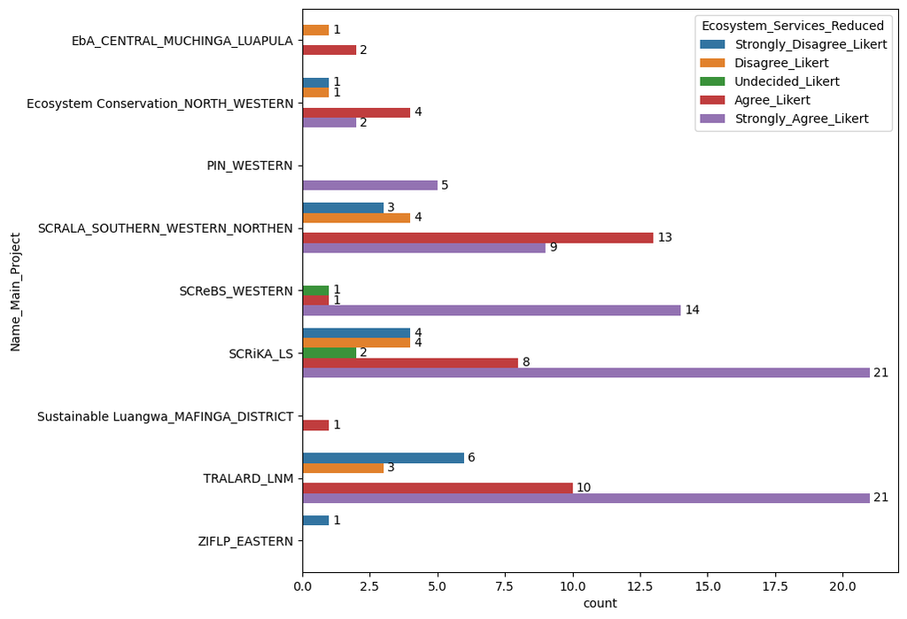

```python
plt.figure(figsize=(8.7, 8.27))
hue_order = ["Strongly_Disagree_Likert", "Disagree_Likert", "Undecided_Likert", "Agree_Likert", "Strongly_Agree_Likert"]
ax = sns.barplot(data = ESR_grouped1, x="count", y="Name_Main_Project", hue="Ecosystem_Services_Reduced", hue_order=hue_order, legend=True)
plt.legend(title="Ecosystem_Services_Reduced")
for container in ax.containers:
    ax.bar_label(container, fmt="%.0f", label_type="edge", padding=3)
plt.show()
```

11.9 Main project and Deforestation Increase

```python
DI_grouped = df2.groupby('Name_Main_Project')['Deforestaion_Increased'].value_counts(dropna=False)
```

```python
DI_grouped1 = pd.DataFrame(DI_grouped)
```

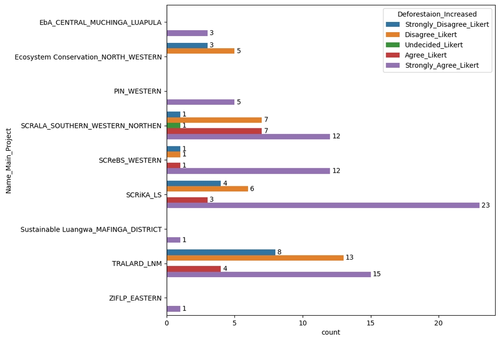

```python
plt.figure(figsize=(8.7, 8.27))
hue_order = ["Strongly_Disagree_Likert", "Disagree_Likert", "Undecided_Likert", "Agree_Likert", "Strongly_Agree_Likert"]
ax = sns.barplot(data = DI_grouped1, x="count", y="Name_Main_Project", hue="Deforestaion_Increased", hue_order=hue_order, legend=True)
plt.legend(title="Deforestaion_Increased")
for container in ax.containers:
    ax.bar_label(container, fmt="%.0f", label_type="edge", padding=3)
plt.show()
```

11.10 Main project and Protected Areas as a Hinderance

```python
PAHL_grouped = df2.groupby('Name_Main_Project')['Protected_Areas_Hinderarnce_Livelihood'].value_counts(dropna=False)
```

```python
PAHL_grouped1 = pd.DataFrame(PAHL_grouped)
```

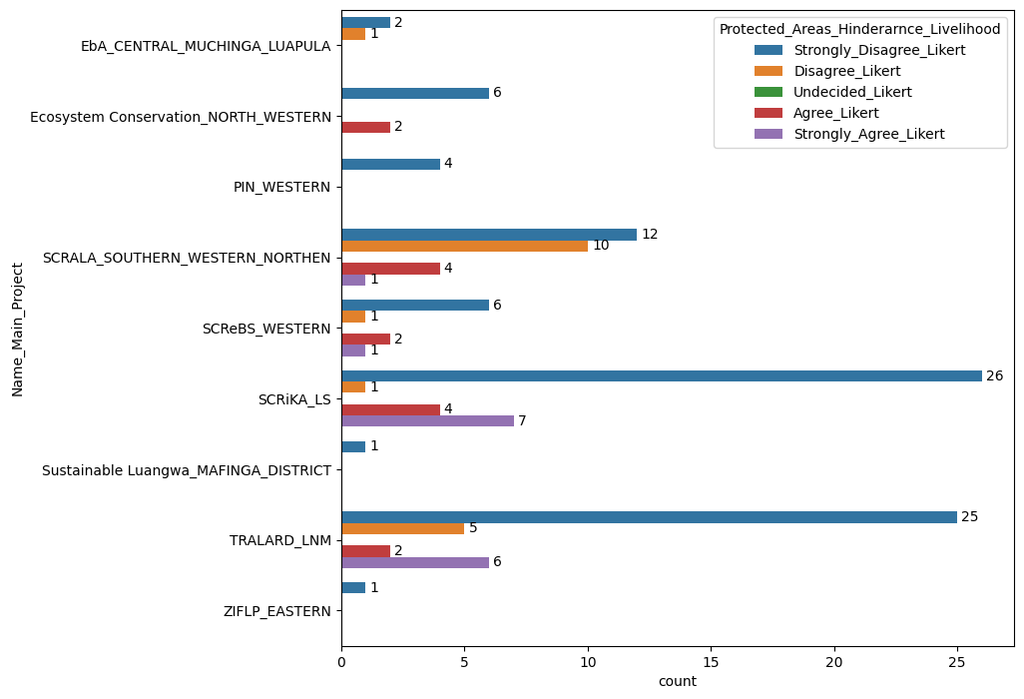

```python
plt.figure(figsize=(8.7, 8.27))
hue_order = ["Strongly_Disagree_Likert", "Disagree_Likert", "Undecided_Likert", "Agree_Likert", "Strongly_Agree_Likert"]
ax = sns.barplot(data = PAHL_grouped1, x="count", y="Name_Main_Project", hue="Protected_Areas_Hinderarnce_Livelihood", hue_order=hue_order, legend=True)
plt.legend(title="Protected_Areas_Hinderarnce_Livelihood")
for container in ax.containers:
    ax.bar_label(container, fmt="%.0f", label_type="edge", padding=3)
plt.show()
```

11.11 Main project and New Livelihood Projects

```python
NLP_grouped = df2.groupby('Name_Main_Project')['New_Livelihood_Projects'].value_counts(dropna=False)
```

```python
NLP_grouped1 = pd.DataFrame(NLP_grouped)
```

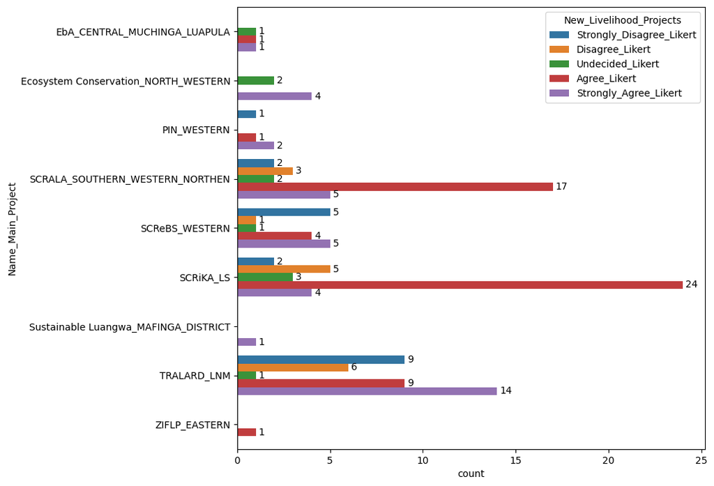

```python
plt.figure(figsize=(8.7, 8.27))
hue_order = ["Strongly_Disagree_Likert", "Disagree_Likert", "Undecided_Likert", "Agree_Likert", "Strongly_Agree_Likert"]
ax = sns.barplot(data = NLP_grouped1, x="count", y="Name_Main_Project", hue="New_Livelihood_Projects", hue_order=hue_order, legend=True)
plt.legend(title="New_Livelihood_Projects")
for container in ax.containers:
    ax.bar_label(container, fmt="%.0f", label_type="edge", padding=3)
plt.show()
```

11.12 Main project and Sustainability of Subprojects

```python
SSC_grouped = df2.groupby('Name_Main_Project')['Subprojects_Sustainability_Contribution'].value_counts(dropna=False)
```

```python
SSC_grouped1 = pd.DataFrame(SSC_grouped)
```

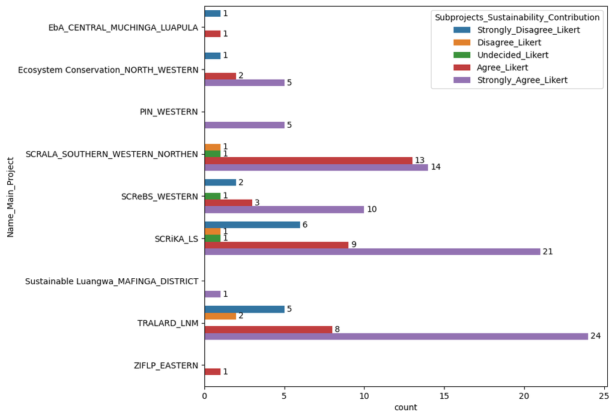

```python
plt.figure(figsize=(8.7, 8.27))
hue_order = ["Strongly_Disagree_Likert", "Disagree_Likert", "Undecided_Likert", "Agree_Likert", "Strongly_Agree_Likert"]
ax = sns.barplot(data = SSC_grouped1, x="count", y="Name_Main_Project", hue="Subprojects_Sustainability_Contribution", hue_order=hue_order, legend=True)
plt.legend(title="Subprojects_Sustainability_Contribution")
for container in ax.containers:
    ax.bar_label(container, fmt="%.0f", label_type="edge", padding=3)
plt.show()
```

```python
cd /Data_Analysis/Data_Analysis
jupyter nbconvert --to html Data_Analysis.ipynb
```

```
  Cell In[161], line 2
    jupyter nbconvert --to html Data_Analysis.ipynb
            ^
SyntaxError: invalid syntax
```

```python
ipython nbconvert --to HTML your_notebook.ipynb
```

```
  Cell In[4], line 1
    ipython nbconvert --to HTML your_notebook.ipynb
            ^
SyntaxError: invalid syntax
```

```python
os.system('jupyter nbconvert --to html Data_Analysis.ipynb')
```

```
---------------------------------------------------------------------------
NameError                                 Traceback (most recent call last)
Cell In[163], line 1
----> 1 os.system('jupyter nbconvert --to html Data_Analysis.ipynb')

NameError: name 'os' is not defined
```

```python
ls /Data_Analysis/Data_Analysis
```

```
Parameterformat nicht ordnungsgemÃ¤ÃŸ - "Data_Analysis".
```

```python
ipython nbconvert --to html Data_Analysis.ipynb
```

```
  Cell In[164], line 1
    ipython nbconvert --to html Data_Analysis.ipynb
            ^
SyntaxError: invalid syntax
```